# Formula 1 lap predictor Machine learning- All Drivers one track

This notebook loads the finalized exports from `formula1_lap_predictionDataAnalysis.ipynb` It is based on features of drivers input and envirmiroment surrounding conditions. It uses the Offical F1 information that was recorded by the broadcasted and stored in FastF1 API.Datasets are a csv files and represents diffrent session from free practices, quаlification and races in the past three year (2023,2024,2025).Then you choose one **track** in this case Italian grand prix (there two italian grand prix in the F1 calendar the other one is called Emilia Romania) and one lap to predict. The it will use filtered data set from the Data Analysis notebook and build model around it to see which fit the best. It trains and compares three PyTorch Forecasting models on that slice: **TFT**, **N-HiTS**, and **N-BEATS**.

[figure not shown]

That makes the notebook is update version of the `formula1_One_driver_lap_predictor.ipynb` I do this to see that are the limit of the AI when we upscale and try to understand if it possible to purcues the original idea to make prediction for each of the 24 track for all 20 drivers with one individual model.

Martin Simeonov, 2026

## Load the data

Now I will load the data from the filter dataset based of the Data Analysis part. To give more context later for the model I should prefer to load the version with the telemetry, which is the detail input from the driver to the car, which should help a lot to the model, because it can adjust the predition of the driver behavior during each part of the lap.

```python
import os

import numpy as np
import pandas as pd

BASE_DIR = r"C:\Fontys\Sem4AIRemaster\IndividualProject"
CLEAN_LAPS_WITH_TELEMETRY_CSV = os.path.join(BASE_DIR, "clean_all_session_laps_with_telemetry.csv")
CLEAN_LAPS_CSV = os.path.join(BASE_DIR, "clean_all_session_laps.csv")

# This notebook should use the finalized data exports only
# Data cleaning and telemetry merging belong to the analysis notebook
USE_EXPORTED_CLEAN_LAPS_WITH_TELEMETRY = True
USE_EXPORTED_CLEAN_LAPS = True

# How to use the official `Deleted` and `IsAccurate` flags (same meanings as the one-driver notebook).
#   "baseline"       keep all laps that pass basic LapTime checks (may include Deleted laps).
#   "deleted_only"   drop laps where Deleted is true
#   "filtered"       deleted_only plus keep only IsAccurate=True when that column exists.
RACE_ROW_FILTER_MODE = "deleted_only"

# Pit laps are strategy-driven and create big onelap time difference around 20sec that this pace model cannot know in advance.
# Keep this True to drop all pit-in pit-out laps before training and evaluation.
EXCLUDE_PIT_ACTIVITY_LAPS = True

practice_idents = {"FP1", "FP2", "FP3"}
USE_TELEMETRY_FEATURES = True
USE_TELEMETRY_PRACTICE_PROFILE = True
USE_TELEMETRY_PREV_LAP = True
USE_TELEMETRY_ROLLING_HISTORY = True
TELEMETRY_ROLLING_WINDOWS = [3, 5]
USE_WEATHER_HISTORY_FEATURES = True
WEATHER_HISTORY_WINDOWS = [3, 5, 10]

SESSION_IDENT = "R"
SELECT_TRACK = "Italian Grand Prix"
# None  do not filter by year; if you want first filter by track `SELECT_TRACK` then from all matching years it will take the last availalbe one
TARGET_YEAR_OVERRIDE = None
# None  take the chronologically last row in the candidate table (same as one-driver iloc[-1]).
# Round is calendar-dependent across seasons and rounds changes, so I leave this as None unless you want one exact weekend.
TARGET_ROUND_OVERRIDE = None
# Target lap for the for the prediction.
PREDICT_LAP = 30

# True: train, val, test = one GP only, split by laps per driver (all drivers).
# False: old split across all events I build it like this for later one update for all tracks prediction.
SINGLE_TARGET_RACE_SPLIT = True

loaded_laps_source_label = ""

if USE_EXPORTED_CLEAN_LAPS_WITH_TELEMETRY and os.path.exists(CLEAN_LAPS_WITH_TELEMETRY_CSV):
    laps = pd.read_csv(CLEAN_LAPS_WITH_TELEMETRY_CSV, low_memory=False)
    loaded_laps_source_label = "Loaded clean laps and telemetry CSV:"
elif USE_EXPORTED_CLEAN_LAPS and os.path.exists(CLEAN_LAPS_CSV):
    laps = pd.read_csv(CLEAN_LAPS_CSV, low_memory=False)
    loaded_laps_source_label = "Loaded clean laps CSV:"
else:
    raise FileNotFoundError(
        "No exported clean laps file was found. Run formula1_lap_predictionDataAnalysis.ipynb first "
        "so the modelling notebook can load the finalized dataset."
    )

print(loaded_laps_source_label)
print("Loaded rows:", len(laps))
print("Loaded years:", sorted(pd.to_numeric(laps["Year"], errors="coerce").dropna().astype(int).unique().tolist()))
```

```
Loaded clean laps and telemetry CSV:
Loaded rows: 180874
Loaded years: [2023, 2024, 2025]
```

### Scope rules in this notebook

```python
def safe_shifted_rolling_mean(series: pd.Series, window: int) -> pd.Series:
    shifted = pd.to_numeric(series, errors="coerce").shift(1)
    return shifted.rolling(window, min_periods=1).apply(
        lambda values: np.nan if np.isnan(values).all() else float(np.nanmean(values)),
        raw=True,
    )


def safe_rolling_mean(series: pd.Series, window: int) -> pd.Series:
    values = pd.to_numeric(series, errors="coerce")
    return values.rolling(window, min_periods=1).apply(
        lambda arr: np.nan if np.isnan(arr).all() else float(np.nanmean(arr)),
        raw=True,
    )

def extract_loaded_telemetry_rows(laps_df: pd.DataFrame) -> pd.DataFrame:
    telemetry_key_cols = ["Year", "Round", "EventName", "DriverNumber", "SessionIdent", "LapNumber"]
    telemetry_feature_cols = sorted(c for c in laps_df.columns if c.startswith("tel_"))

    if not telemetry_feature_cols or not all(col in laps_df.columns for col in telemetry_key_cols):
        return pd.DataFrame(columns=telemetry_key_cols + telemetry_feature_cols)

    tel_non_null_mask = laps_df[telemetry_feature_cols].notna().any(axis=1)
    out = laps_df.loc[tel_non_null_mask, telemetry_key_cols + telemetry_feature_cols].copy()
    out = out.dropna(subset=telemetry_key_cols).copy()
    out = out.drop_duplicates(telemetry_key_cols, keep="last").reset_index(drop=True)
    return out


def flatten_columns(df: pd.DataFrame) -> pd.DataFrame:
    df = df.copy()
    df.columns = [
        "_".join([part for part in col if part]) if isinstance(col, tuple) else col
        for col in df.columns
    ]
    return df


def build_practice_profile(telemetry_lap_features: pd.DataFrame) -> pd.DataFrame:
    if telemetry_lap_features.empty:
        return pd.DataFrame(columns=["Year", "Round", "EventName", "DriverNumber"])

    grp_cols = ["Year", "Round", "EventName", "DriverNumber"]
    lap_metric_cols = [
        "tel_lap_duration_s",
        "tel_speed_mean",
        "tel_speed_max",
        "tel_speed_std",
        "tel_rpm_mean",
        "tel_gear_mean",
        "tel_throttle_mean",
        "tel_throttle_on_ratio",
        "tel_brake_on_ratio",
        "tel_drs_on_ratio",
        "tel_samples",
    ]
    lap_metric_cols = [col for col in lap_metric_cols if col in telemetry_lap_features.columns]

    agg_map = {col: ["mean", "std", "min", "max"] for col in lap_metric_cols}
    agg_map["LapNumber"] = ["count"]
    agg_map["SessionIdent"] = ["nunique"]

    practice_profile = telemetry_lap_features.groupby(grp_cols, as_index=False).agg(agg_map)
    practice_profile = flatten_columns(practice_profile)
    practice_profile = practice_profile.rename(columns={
        "Year_": "Year",
        "Round_": "Round",
        "EventName_": "EventName",
        "DriverNumber_": "DriverNumber",
        "LapNumber_count": "practice_lap_count",
        "SessionIdent_nunique": "practice_session_count",
    })

    best_lap_idx = (
        telemetry_lap_features
        .dropna(subset=["tel_lap_duration_s"])
        .groupby(grp_cols)["tel_lap_duration_s"]
        .idxmin()
    )
    best_laps = telemetry_lap_features.loc[best_lap_idx].copy()

    best_keep = grp_cols + [
        "SessionIdent",
        "LapNumber",
        "tel_lap_duration_s",
        "tel_speed_mean",
        "tel_speed_max",
        "tel_speed_std",
        "tel_rpm_mean",
        "tel_gear_mean",
        "tel_throttle_mean",
        "tel_throttle_on_ratio",
        "tel_brake_on_ratio",
        "tel_drs_on_ratio",
        "tel_samples",
    ]
    best_keep = [col for col in best_keep if col in best_laps.columns]
    best_laps = best_laps[best_keep].rename(columns={
        "SessionIdent": "best_practice_session",
        "LapNumber": "best_practice_lap_number",
        "tel_lap_duration_s": "best_practice_lap_duration_s",
        "tel_speed_mean": "best_practice_speed_mean",
        "tel_speed_max": "best_practice_speed_max",
        "tel_speed_std": "best_practice_speed_std",
        "tel_rpm_mean": "best_practice_rpm_mean",
        "tel_gear_mean": "best_practice_gear_mean",
        "tel_throttle_mean": "best_practice_throttle_mean",
        "tel_throttle_on_ratio": "best_practice_throttle_on_ratio",
        "tel_brake_on_ratio": "best_practice_brake_on_ratio",
        "tel_drs_on_ratio": "best_practice_drs_on_ratio",
        "tel_samples": "best_practice_samples",
    })

    practice_profile = practice_profile.merge(best_laps, on=grp_cols, how="left")
    return practice_profile


def build_event_weather_history(df: pd.DataFrame, windows: list[int]) -> pd.DataFrame:
    """Build leakage-safe event weather history features from previous laps only."""
    if df.empty or "event_id" not in df.columns or "LapNumber" not in df.columns:
        return pd.DataFrame(columns=["event_id", "LapNumber"])

    work = df.copy()

    # Make weather columns numeric inside the function so later code does not depend
    # on outside conversion blocks.
    if "weather_Rainfall" in work.columns:
        rainfall_str = work["weather_Rainfall"].astype("string").str.strip().str.lower()
        work["weather_Rainfall"] = rainfall_str.replace(
            {"true": 1.0, "false": 0.0, "nan": np.nan, "none": np.nan, "": np.nan}
        )
        work["weather_Rainfall"] = pd.to_numeric(work["weather_Rainfall"], errors="coerce").fillna(0.0)

    for col in [
        "weather_AirTemp",
        "weather_TrackTemp",
        "weather_Humidity",
        "weather_Pressure",
        "weather_WindSpeed",
        "weather_WindDirection",
    ]:
        if col in work.columns:
            work[col] = pd.to_numeric(work[col], errors="coerce")

    agg_map = {}
    if "weather_Rainfall" in work.columns:
        agg_map["weather_Rainfall"] = "mean"
    if "weather_AirTemp" in work.columns:
        agg_map["weather_AirTemp"] = "median"
    if "weather_TrackTemp" in work.columns:
        agg_map["weather_TrackTemp"] = "median"
    if "weather_Humidity" in work.columns:
        agg_map["weather_Humidity"] = "median"
    if "weather_Pressure" in work.columns:
        agg_map["weather_Pressure"] = "median"
    if "weather_WindSpeed" in work.columns:
        agg_map["weather_WindSpeed"] = "median"

    if not agg_map:
        return pd.DataFrame(columns=["event_id", "LapNumber"])

    event_weather = (
        work.groupby(["event_id", "LapNumber"], as_index=False)
        .agg(agg_map)
        .sort_values(["event_id", "LapNumber"])
        .reset_index(drop=True)
    )

    event_weather = event_weather.rename(columns={
        "weather_Rainfall": "event_weather_rain_now",
        "weather_AirTemp": "event_weather_airtemp_now",
        "weather_TrackTemp": "event_weather_tracktemp_now",
        "weather_Humidity": "event_weather_humidity_now",
        "weather_Pressure": "event_weather_pressure_now",
        "weather_WindSpeed": "event_weather_windspeed_now",
    })

    derived_cols = []
    base_cols = [c for c in event_weather.columns if c.startswith("event_weather_") and c.endswith("_now")]

    for base_col in base_cols:
        base_series = event_weather.groupby("event_id")[base_col]
        for window in windows:
            suffix = "ratio" if "rain" in base_col else "mean"
            new_col = base_col.replace("_now", f"_prev{int(window)}_{suffix}")
            event_weather[new_col] = base_series.transform(
                lambda s, w=int(window): safe_shifted_rolling_mean(s, w)
            )
            derived_cols.append(new_col)

    if "event_weather_rain_prev5_ratio" in event_weather.columns:
        rain_ratio = event_weather["event_weather_rain_prev5_ratio"].fillna(0.0)
        event_weather["event_weather_rain_regime_code"] = np.select(
            [rain_ratio >= 0.6, rain_ratio >= 0.05],
            [2.0, 1.0],
            default=0.0,
        )
        derived_cols.append("event_weather_rain_regime_code")

    keep_cols = ["event_id", "LapNumber"] + sorted(set(derived_cols))
    return event_weather[keep_cols].copy()


def build_previous_year_reference_features(df: pd.DataFrame) -> tuple[pd.DataFrame, pd.DataFrame]:
    """Build simple previous-year pace references to help the model track car evolution."""
    if df.empty:
        empty_event = pd.DataFrame(columns=["Year", "EventName", "event_prev_year_median_lap_s", "event_prev_year_fastest_lap_s"])
        empty_team = pd.DataFrame(columns=["Year", "EventName", "TeamName", "team_prev_year_median_lap_s"])
        return empty_event, empty_team

    # Match by track name across seasons.
    event_ref = (
        df.groupby(["Year", "EventName"], as_index=False)
        .agg(
            event_prev_year_median_lap_s=("LapTime_s", "median"),
            event_prev_year_fastest_lap_s=("LapTime_s", "min"),
        )
    )
    event_ref["Year"] = event_ref["Year"] + 1

    team_ref = (
        df.dropna(subset=["TeamName"])
        .groupby(["Year", "EventName", "TeamName"], as_index=False)
        .agg(team_prev_year_median_lap_s=("LapTime_s", "median"))
    )
    team_ref["Year"] = team_ref["Year"] + 1

    return event_ref, team_ref
```

### Function explained

- safe_shifted_rolling_mean This takes a column and shift it by 1 row and the it calculate the average over the previous window. I use 1 so if we are on lap 10 to use only laps 1-9 data to avoid data leaks. It used for the avr speed, throttle and weather.
- safe_rolling_mean the idea is the same as the previous function but it now it include the current row
- extract_loaded_telemetry_rows THies fuction will extrack only the tel information and will create telemetry table ony from the main laps dataset
- flatten_columns I had multiplease aggrigation in the dataset like "tel_speed_mean", "mean" and "tel_speed_mean", "std" and will make them into seprate columns It makes grouped summary tables easier to merge and read
- build_practice_profile It create a practice summary for each of the drivers for the practive based of the telemetry info. Since in practice before the actial race everyone use the information and result from FP to get idea where they driver aims to finish in race conditions
- build_event_weather_history based of the analysis they weather typically does not drastically change that much and 20 drivers give the save info about hte weather over one lap and for that reason i previous-lap rolling history features like rain, track temp, humidity
- build_previous_year_reference_features it calculate the previouse year median lap times and fastest lap and it get referncase for 2025 from 2024 about how year team lap time and over all performance, bacause the car changes all the times by introducing updates. THis fuction will give later on the model historical baseline for normal lap pace look at this track and how much the team improved or regress.

## Build the final race only dataset for the model

This cell load the telemetry features with clean keys and filter the race laps base of the criterias it also remove the pit activity laps. It also execute the functions we defiene earlier.

```python
def to_bool_flag(series: pd.Series, default_false: bool = True) -> pd.Series:
    """Convert mixed bool/string columns into a clean boolean mask."""
    text = series.astype("string").str.strip().str.lower()
    mapped = text.map(
        {
            "true": True,
            "false": False,
            "1": True,
            "0": False,
            "1.0": True,
            "0.0": False,
            "yes": True,
            "no": False,
            "y": True,
            "n": False,
            "t": True,
            "f": False,
        }
    )
    return mapped.fillna(False if default_false else True).astype(bool)
```

```python
tel_lap_feats_all = extract_loaded_telemetry_rows(laps)

tel_lap_feats = tel_lap_feats_all[tel_lap_feats_all["SessionIdent"].isin(practice_idents)].copy()
print("Practice telemetry lap features:", tel_lap_feats.shape)

if USE_TELEMETRY_PRACTICE_PROFILE:
    practice_profile = build_practice_profile(tel_lap_feats)
    print("Built practice profile from exported telemetry rows:", practice_profile.shape)
else:
    practice_profile = pd.DataFrame(columns=["Year", "Round", "EventName", "DriverNumber"])
    print("Practice profile features are disabled.")

want_session = str(SESSION_IDENT).strip().upper()
race_candidates = laps[laps["SessionIdent"] == want_session].copy()

if race_candidates.empty:
    available_sessions = sorted(laps["SessionIdent"].dropna().unique().tolist())[:20]
    raise ValueError(
        f"No race rows were found with SessionIdent={want_session!r}. "
        f"Available session values include: {available_sessions}"
    )

race_candidates = race_candidates.dropna(
    subset=["Year", "Round", "DriverNumber", "LapNumber", "LapTime_s"]
).copy()

race_candidates = race_candidates[(race_candidates["LapTime_s"] > 40) & (race_candidates["LapTime_s"] < 300)].copy()

baseline_race_df = race_candidates.copy()

deleted_only_race_df = baseline_race_df.copy()
if "Deleted" in deleted_only_race_df.columns:
    deleted_mask = to_bool_flag(deleted_only_race_df["Deleted"], default_false=True)
    deleted_only_race_df = deleted_only_race_df.loc[~deleted_mask].copy()

filtered_race_df = deleted_only_race_df.copy()
if "IsAccurate" in filtered_race_df.columns:
    accurate_mask = to_bool_flag(filtered_race_df["IsAccurate"], default_false=False)
    filtered_race_df = filtered_race_df.loc[accurate_mask].copy()

_mode = str(RACE_ROW_FILTER_MODE).strip().lower()
if _mode == "baseline":
    race_df = baseline_race_df.copy()
elif _mode == "deleted_only":
    race_df = deleted_only_race_df.copy()
elif _mode == "filtered":
    if not filtered_race_df.empty:
        race_df = filtered_race_df.copy()
    elif not deleted_only_race_df.empty:
        print("Warning: filtered removed all rows, falling back to deleted_only.")
        race_df = deleted_only_race_df.copy()
    else:
        print("Warning: filtered removed all rows, falling back to baseline.")
        race_df = baseline_race_df.copy()
else:
    raise ValueError(f"Unknown RACE_ROW_FILTER_MODE: {RACE_ROW_FILTER_MODE!r}")

pit_activity_removed = 0
if globals().get("EXCLUDE_PIT_ACTIVITY_LAPS", True):
    pit_cols = [col for col in ["PitInTime", "PitOutTime"] if col in race_df.columns]
    if pit_cols:
        pit_mask = race_df[pit_cols].notna().any(axis=1)
        pit_activity_removed = int(pit_mask.sum())
        if pit_activity_removed > 0:
            race_df = race_df.loc[~pit_mask].copy()

print("Race filter mode used:", RACE_ROW_FILTER_MODE)
print("Race rows after baseline:", len(baseline_race_df))
print("Race rows after deleted_only:", len(deleted_only_race_df))
print("Race rows after filtered:", len(filtered_race_df))
print("Pit-activity laps removed:", pit_activity_removed)

race_df = race_df.sort_values(["Year", "Round", "EventName", "DriverNumber", "LapNumber"]).copy()

race_df["event_id"] = (
    race_df["Year"].astype(int).astype(str)
    + "_R" + race_df["Round"].astype(int).astype(str).str.zfill(2)
    + "_" + race_df["EventName"].astype(str)
)

race_df["series_id"] = (
    race_df["event_id"] + "_D" + race_df["DriverNumber"].astype(int).astype(str)
)

race_df["time_idx"] = race_df.groupby("series_id").cumcount() + 1
race_df["year_real"] = race_df["Year"].astype(float)
race_df["round_real"] = race_df["Round"].astype(float)
race_df["lap_idx_real"] = race_df["LapNumber"].astype(float)

race_df["race_lap_count"] = race_df.groupby("series_id")["LapNumber"].transform("max").astype(float)
race_df["lap_progress_ratio"] = (
    race_df["LapNumber"].astype(float)
    / race_df["race_lap_count"].replace(0, np.nan)
)

race_df["lap_phase"] = np.select(
    [race_df["lap_progress_ratio"] <= 0.33, race_df["lap_progress_ratio"] <= 0.66],
    ["start", "mid"],
    default="end",
)
```

```
Practice telemetry lap features: (68790, 16)
Built practice profile from exported telemetry rows: (1424, 58)
Race filter mode used: deleted_only
Race rows after baseline: 75666
Race rows after deleted_only: 75666
Race rows after filtered: 66924
Pit-activity laps removed: 4596
```

## Select The Target Race

After I extra the practice profiles and the race data let pick the exact race row from `SELECT_TRACK` plus the optional year what I define at the top then drops every other weekend from `race_df`.

```python
required_config_names = [
    "SELECT_TRACK",
    "TARGET_YEAR_OVERRIDE",
    "TARGET_ROUND_OVERRIDE",
    "SINGLE_TARGET_RACE_SPLIT",
    "PREDICT_LAP",
    "SESSION_IDENT",
]

matching_target_event_ids = []
effective_target_year = None
effective_target_round = None
selected_target_event_id = None
selected_target_event_name = None

prelim_event_calendar = (
    race_df[["Year", "Round", "EventName", "event_id"]]
    .drop_duplicates()
    .sort_values(["Year", "Round", "EventName"])
    .reset_index(drop=True)
)

_track_kw = str(SELECT_TRACK).strip()
candidate_target_events = (
    prelim_event_calendar[
        prelim_event_calendar["EventName"].astype(str).str.contains(_track_kw, case=False, na=False)
    ]
    .drop_duplicates(subset=["Year", "Round", "EventName", "event_id"], keep="last")
    .sort_values(["Year", "Round", "EventName"])
    .reset_index(drop=True)
)
if TARGET_YEAR_OVERRIDE is not None:
    candidate_target_events = candidate_target_events[
        pd.to_numeric(candidate_target_events["Year"], errors="coerce") == int(TARGET_YEAR_OVERRIDE)
    ].reset_index(drop=True)
if TARGET_ROUND_OVERRIDE is not None:
    candidate_target_events = candidate_target_events[
        pd.to_numeric(candidate_target_events["Round"], errors="coerce") == int(TARGET_ROUND_OVERRIDE)
    ].reset_index(drop=True)
if candidate_target_events.empty:
    raise ValueError(
        "No calendar row matched SELECT_TRACK after filters. "
        f"SELECT_TRACK={SELECT_TRACK!r}, TARGET_YEAR_OVERRIDE={TARGET_YEAR_OVERRIDE!r}, "
        f"TARGET_ROUND_OVERRIDE={TARGET_ROUND_OVERRIDE!r}"
    )

matching_target_event_ids = candidate_target_events["event_id"].astype(str).tolist()
print("Single race mode: keeping only the chosen GP in race_df before practice/telemetry merges and training.")
print("Candidate target races (after year/round filters):")
display(candidate_target_events[["Year", "Round", "EventName", "event_id"]])

_picked = candidate_target_events.iloc[-1]
selected_target_event_id = str(_picked["event_id"])
selected_target_event_name = str(_picked["EventName"])
effective_target_year = int(pd.to_numeric(_picked["Year"], errors="coerce"))
effective_target_round = int(pd.to_numeric(_picked["Round"], errors="coerce"))

_n_before_scope = len(race_df)
race_df = race_df[race_df["event_id"] == selected_target_event_id].copy()
print(f"Scoped race_df: {_n_before_scope} to {len(race_df)} rows for event_id={selected_target_event_id!r}")
```

```
Single race mode: keeping only the chosen GP in race_df before practice/telemetry merges and training.
Candidate target races (after year/round filters):
```

|  | Year | Round | EventName | event_id |
| --- | --- | --- | --- | --- |
| 0 | 2023 | 14 | Italian Grand Prix | 2023_R14_Italian Grand Prix |
| 1 | 2024 | 16 | Italian Grand Prix | 2024_R16_Italian Grand Prix |
| 2 | 2025 | 16 | Italian Grand Prix | 2025_R16_Italian Grand Prix |

```
Scoped race_df: 71070 to 912 rows for event_id='2025_R16_Italian Grand Prix'
```

## Merge the same weekend race features and split

```python
event_calendar = (
    race_df[["Year", "Round", "EventName", "event_id"]]
    .drop_duplicates()
    .sort_values(["Year", "Round", "EventName"])
    .reset_index(drop=True)
)
event_calendar["event_order_real"] = np.arange(1, len(event_calendar) + 1, dtype=float)
event_calendar["season_progress_ratio"] = 1.0

race_df = race_df.merge(
    event_calendar[["event_id", "event_order_real", "season_progress_ratio"]],
    on="event_id",
    how="left",
)

# Reuse older seasons of the same exported race table to give the models a simple
# reference for how quick this circuit was in the previous season.
reference_race_df = laps.copy()
reference_race_df = reference_race_df.dropna(subset=["Year", "Round", "EventName", "LapTime_s"]).copy()

event_prev_year_ref, team_prev_year_ref = build_previous_year_reference_features(reference_race_df)
if not event_prev_year_ref.empty:
    race_df = race_df.merge(event_prev_year_ref, on=["Year", "EventName"], how="left")
if not team_prev_year_ref.empty and "TeamName" in race_df.columns:
    race_df = race_df.merge(team_prev_year_ref, on=["Year", "EventName", "TeamName"], how="left")

print("Previous-year same-track reference features merged from exported race history.")

if USE_WEATHER_HISTORY_FEATURES:
    event_weather_history = build_event_weather_history(race_df, WEATHER_HISTORY_WINDOWS)
    if not event_weather_history.empty:
        race_df = race_df.merge(event_weather_history, on=["event_id", "LapNumber"], how="left")
        weather_history_cols = [c for c in race_df.columns if c.startswith("event_weather_")]
        print("Weather history columns:", len(weather_history_cols))
    else:
        print("Weather history features were enabled, but no weather columns were available.")
else:
    print("Weather history features are disabled.")

if USE_TELEMETRY_PRACTICE_PROFILE:
    practice_profile_local = practice_profile.copy() if not practice_profile.empty else pd.DataFrame()
    if not practice_profile_local.empty:
        for col in ["Year", "Round", "DriverNumber"]:
            practice_profile_local[col] = pd.to_numeric(practice_profile_local[col], errors="coerce")
        practice_profile_local = practice_profile_local[
            (practice_profile_local["Year"] == effective_target_year)
            & (practice_profile_local["Round"] == effective_target_round)
            & (practice_profile_local["EventName"] == selected_target_event_name)
        ].copy()

    # Rebuild the selected-event practice summary when the selected weekend
    # has practice telemetry rows but no merged practice summary yet.
    if practice_profile_local.empty and not tel_lap_feats.empty:
        practice_tel_selected = tel_lap_feats.copy()
        practice_tel_selected["Year"] = pd.to_numeric(practice_tel_selected["Year"], errors="coerce")
        practice_tel_selected["Round"] = pd.to_numeric(practice_tel_selected["Round"], errors="coerce")
        practice_tel_selected = practice_tel_selected[
            (practice_tel_selected["Year"] == effective_target_year)
            & (practice_tel_selected["Round"] == effective_target_round)
            & (practice_tel_selected["EventName"] == selected_target_event_name)
        ].copy()
        if not practice_tel_selected.empty:
            practice_profile_local = build_practice_profile(practice_tel_selected)
            print("Rebuilt same-weekend practice profile from telemetry cache for the selected event.")

    if not practice_profile_local.empty:
        race_df = race_df.merge(
            practice_profile_local,
            on=["Year", "Round", "EventName", "DriverNumber"],
            how="left",
        )
        practice_cols = [
            c for c in race_df.columns
            if c.startswith("practice_") or c.startswith("best_practice_") or (c.startswith("tel_") and not c.startswith("tel_prev_"))
        ]
        if practice_cols:
            frac = float(race_df[practice_cols[0]].notna().mean())
            print("Same-weekend practice telemetry merged.", f"Race rows with practice telemetry: {100.0 * frac:.1f}%")
    else:
        print("No same-weekend practice telemetry profile was available for the selected event.")
else:
    print("Practice profile telemetry is disabled.")

if USE_TELEMETRY_PREV_LAP and not tel_lap_feats_all.empty:
    tel_lap_feats_race = tel_lap_feats_all[
        tel_lap_feats_all["SessionIdent"].astype(str).str.strip().str.upper() == str(SESSION_IDENT).strip().upper()
    ].copy()
    tel_lap_feats_race["Year"] = pd.to_numeric(tel_lap_feats_race["Year"], errors="coerce")
    tel_lap_feats_race["Round"] = pd.to_numeric(tel_lap_feats_race["Round"], errors="coerce")
    tel_lap_feats_race["DriverNumber"] = pd.to_numeric(tel_lap_feats_race["DriverNumber"], errors="coerce")
    tel_lap_feats_race["LapNumber"] = pd.to_numeric(tel_lap_feats_race["LapNumber"], errors="coerce")
    tel_lap_feats_race = tel_lap_feats_race[
        (tel_lap_feats_race["Year"] == effective_target_year)
        & (tel_lap_feats_race["Round"] == effective_target_round)
        & (tel_lap_feats_race["EventName"] == selected_target_event_name)
    ].copy()
    if not tel_lap_feats_race.empty:
        tel_metric_cols = [c for c in tel_lap_feats_race.columns if c.startswith("tel_")]
        tel_prev = tel_lap_feats_race[["Year", "Round", "EventName", "DriverNumber", "LapNumber"] + tel_metric_cols].copy()
        tel_prev["LapNumber"] = tel_prev["LapNumber"] + 1
        tel_prev = tel_prev.rename(columns={c: c.replace("tel_", "tel_prev_", 1) for c in tel_metric_cols})
        race_df = race_df.merge(
            tel_prev,
            on=["Year", "Round", "EventName", "DriverNumber", "LapNumber"],
            how="left",
        )
        tel_prev_cols = [c for c in race_df.columns if c.startswith("tel_prev_")]
        if tel_prev_cols:
            frac = float(race_df[tel_prev_cols[0]].notna().mean())
            print("Same-race previous-lap telemetry merged.", f"Race rows with telemetry: {100.0 * frac:.1f}%")
            if USE_TELEMETRY_ROLLING_HISTORY:
                rolling_source_cols = [c for c in tel_prev_cols if c not in {"tel_prev_samples"}]
                for base_col in rolling_source_cols:
                    short_name = base_col.replace("tel_prev_", "", 1)
                    for window in TELEMETRY_ROLLING_WINDOWS:
                        hist_col = f"tel_hist{int(window)}_{short_name}"
                        race_df[hist_col] = (
                            race_df.groupby("series_id")[base_col]
                            .transform(lambda s, w=int(window): safe_rolling_mean(s, w))
                        )
                tel_hist_cols = [c for c in race_df.columns if c.startswith("tel_hist")]
                print("Rolling telemetry history columns:", len(tel_hist_cols))
    else:
        print("No same-race telemetry rows found for the selected target event.")
else:
    print("Previous-lap race telemetry is disabled or telemetry cache is empty.")

race_df["prev_lap_time_s"] = race_df.groupby("series_id")["LapTime_s"].shift(1)
race_df["prev2_lap_time_s"] = race_df.groupby("series_id")["LapTime_s"].shift(2)
race_df["prev3_lap_time_s"] = race_df.groupby("series_id")["LapTime_s"].shift(3)
race_df["prev_lap_delta_s"] = race_df["prev_lap_time_s"] - race_df["prev2_lap_time_s"]
race_df["rolling_prev3_mean_s"] = race_df.groupby("series_id")["LapTime_s"].transform(lambda s: safe_shifted_rolling_mean(s, 3))
race_df["rolling_prev5_mean_s"] = race_df.groupby("series_id")["LapTime_s"].transform(lambda s: safe_shifted_rolling_mean(s, 5))
race_df["rolling_prev8_mean_s"] = race_df.groupby("series_id")["LapTime_s"].transform(lambda s: safe_shifted_rolling_mean(s, 8))
race_df = race_df.dropna(subset=["prev_lap_time_s"]).copy()
if "event_prev_year_median_lap_s" in race_df.columns:
    race_df["event_prev_year_gap_to_prev_lap_s"] = race_df["prev_lap_time_s"] - race_df["event_prev_year_median_lap_s"]
if "team_prev_year_median_lap_s" in race_df.columns:
    race_df["team_prev_year_gap_to_prev_lap_s"] = race_df["prev_lap_time_s"] - race_df["team_prev_year_median_lap_s"]
race_df["target_delta_s"] = race_df["LapTime_s"] - race_df["prev_lap_time_s"]
race_df["time_idx"] = race_df.groupby("series_id").cumcount() + 1

available_years = [effective_target_year] if effective_target_year is not None else []

print("Duplicate columns:", race_df.columns[race_df.columns.duplicated()].tolist())
print("Available years inside the selected target scope:", available_years)
print("Effective target year:", effective_target_year)
print("Effective target round:", effective_target_round)
print("Matching target event ids:", matching_target_event_ids)
print("Selected target event:", selected_target_event_id)
```

```
Previous-year same-track reference features merged from exported race history.
Weather history columns: 19
Same-weekend practice telemetry merged. Race rows with practice telemetry: 100.0%
Same-race previous-lap telemetry merged. Race rows with telemetry: 95.8%
```

```
Rolling telemetry history columns: 18
Duplicate columns: []
Available years inside the selected target scope: [2025]
Effective target year: 2025
Effective target round: 16
Matching target event ids: ['2023_R14_Italian Grand Prix', '2024_R16_Italian Grand Prix', '2025_R16_Italian Grand Prix']
Selected target event: 2025_R16_Italian Grand Prix
```

Now it will split the data for the model the late model training. Since our target will be the 2025 race hide this data use I will use the the 2023 and 2024 for the train and validation with split of 80% train and 20% valatidation split. Quick reminder the ratio across the driver series inside the historical pool.In the history data set in this case from 2023 and 2024 each driver has series id by combining the event identifier and the driver number, so each unique value represents one driver’s lap sequence in one specific race. This allows the model to group laps correctly, build previous-lap and rolling-history features, and split the data by complete driver sequences instead of mixing laps from different drivers. For test I will use the 2025 data only for testing to avoid any race information for the race just what you will do in race prediction before it acctuly happen.

```python
available_years = sorted(candidate_target_events["Year"].dropna().astype(int).unique().tolist())
selected_target_year = int(effective_target_year)
selected_target_round = int(effective_target_round)
selected_target_name = str(selected_target_event_name)
selected_target_event = str(selected_target_event_id)

history_min_len = int(globals().get("MIN_RACE_HISTORY_SEQUENCE_LEN", 5))


def reindex_split_time_idx(df: pd.DataFrame) -> pd.DataFrame:
    if df.empty:
        return df.copy()

    parts = []
    for _, part in df.groupby("series_id", sort=False):
        part = part.sort_values("time_idx").reset_index(drop=True).copy()
        part["time_idx"] = np.arange(1, len(part) + 1)
        parts.append(part)

    return pd.concat(parts, ignore_index=True)


def split_series_train_val_from_history(
    history_df: pd.DataFrame,
    val_fraction: float = 0.2,
    min_len: int = 5,
) -> tuple[pd.DataFrame, pd.DataFrame, list[str]]:
    train_ids = []
    val_ids = []
    dropped_series = []

    for year, year_part in history_df.groupby("Year", sort=True):
        eligible_ids = []

        for series_id, part in year_part.groupby("series_id", sort=True):
            if len(part) < min_len:
                dropped_series.append(str(series_id))
                continue
            eligible_ids.append(str(series_id))

        if not eligible_ids:
            continue

        if len(eligible_ids) == 1:
            train_ids.extend(eligible_ids)
            continue

        val_count = max(1, int(round(len(eligible_ids) * val_fraction)))
        val_count = min(val_count, len(eligible_ids) - 1)
        val_id_set = set(eligible_ids[-val_count:])

        for series_id in eligible_ids:
            if series_id in val_id_set:
                val_ids.append(series_id)
            else:
                train_ids.append(series_id)

    train_df = reindex_split_time_idx(history_df[history_df["series_id"].isin(train_ids)].copy())
    val_df = reindex_split_time_idx(history_df[history_df["series_id"].isin(val_ids)].copy())

    if train_df.empty or val_df.empty:
        raise ValueError(
            "Could not create a valid race-history train/validation split. "
            "Try lowering MIN_RACE_HISTORY_SEQUENCE_LEN."
        )

    return train_df, val_df, dropped_series


def build_selected_track_race_history_df(template_df: pd.DataFrame) -> pd.DataFrame:
    candidate_event_keys = (
        candidate_target_events[["Year", "Round", "EventName"]]
        .drop_duplicates()
        .sort_values(["Year", "Round", "EventName"])
        .reset_index(drop=True)
    )

    candidate_event_keys["event_id"] = (
        candidate_event_keys["Year"].astype(int).astype(str)
        + "_R" + candidate_event_keys["Round"].astype(int).astype(str).str.zfill(2)
        + "_" + candidate_event_keys["EventName"].astype(str)
    )

    candidate_event_keys["event_order_real"] = np.arange(1, len(candidate_event_keys) + 1, dtype=float)
    candidate_event_keys["season_progress_ratio"] = 1.0

    hist_df = laps.copy()
    hist_df["SessionIdent"] = hist_df["SessionIdent"].astype(str).str.strip().str.upper()
    hist_df = hist_df[hist_df["SessionIdent"] == str(SESSION_IDENT).strip().upper()].copy()


    hist_df = hist_df.merge(
        candidate_event_keys[["Year", "Round", "EventName", "event_id", "event_order_real", "season_progress_ratio"]],
        on=["Year", "Round", "EventName"],
        how="inner",
    )

    hist_df = hist_df.dropna(subset=["Year", "Round", "DriverNumber", "LapNumber", "LapTime_s"]).copy()
    hist_df = hist_df[(hist_df["LapTime_s"] > 40) & (hist_df["LapTime_s"] < 300)].copy()

    if "Deleted" in hist_df.columns and str(RACE_ROW_FILTER_MODE).strip().lower() in {"deleted_only", "filtered"}:
        deleted_mask = to_bool_flag(hist_df["Deleted"], default_false=True)
        hist_df = hist_df.loc[~deleted_mask].copy()

    if "IsAccurate" in hist_df.columns and str(RACE_ROW_FILTER_MODE).strip().lower() == "filtered":
        accurate_mask = to_bool_flag(hist_df["IsAccurate"], default_false=False)
        hist_df = hist_df.loc[accurate_mask].copy()

    if globals().get("EXCLUDE_PIT_ACTIVITY_LAPS", True):
        pit_cols = [col for col in ["PitInTime", "PitOutTime"] if col in hist_df.columns]
        if pit_cols:
            pit_mask = hist_df[pit_cols].notna().any(axis=1)
            if int(pit_mask.sum()) > 0:
                hist_df = hist_df.loc[~pit_mask].copy()

    if hist_df.empty:
        raise ValueError(f"No {SELECT_TRACK} race rows were left after cleaning.")

    if "weather_Rainfall" in hist_df.columns:
        hist_df["weather_Rainfall"] = pd.to_numeric(hist_df["weather_Rainfall"], errors="coerce").fillna(0.0)

    for weather_col in [
        "weather_AirTemp",
        "weather_TrackTemp",
        "weather_Humidity",
        "weather_Pressure",
        "weather_WindSpeed",
        "weather_WindDirection",
    ]:
        if weather_col in hist_df.columns:
            hist_df[weather_col] = pd.to_numeric(hist_df[weather_col], errors="coerce")

    hist_df = hist_df.sort_values(["Year", "Round", "EventName", "DriverNumber", "LapNumber"]).copy()
    hist_df["series_id"] = hist_df["event_id"] + "_D" + hist_df["DriverNumber"].astype(int).astype(str)
    hist_df["year_real"] = hist_df["Year"].astype(float)
    hist_df["round_real"] = hist_df["Round"].astype(float)
    hist_df["lap_idx_real"] = hist_df["LapNumber"].astype(float)
    hist_df["race_lap_count"] = hist_df.groupby("series_id")["LapNumber"].transform("max").astype(float)
    hist_df["lap_progress_ratio"] = hist_df["LapNumber"].astype(float) / hist_df["race_lap_count"].replace(0, np.nan)
    hist_df["lap_phase"] = np.select(
        [hist_df["lap_progress_ratio"] <= 0.33, hist_df["lap_progress_ratio"] <= 0.66],
        ["start", "mid"],
        default="end",
    )

    # Build previous-year reference features properly
    reference_hist = hist_df.dropna(subset=["Year", "EventName", "LapTime_s"]).copy()
    event_prev_year_ref, team_prev_year_ref = build_previous_year_reference_features(reference_hist)
```

```python
    if not event_prev_year_ref.empty:
        hist_df = hist_df.merge(event_prev_year_ref, on=["Year", "EventName"], how="left")

    if not team_prev_year_ref.empty and "TeamName" in hist_df.columns:
        hist_df = hist_df.merge(team_prev_year_ref, on=["Year", "EventName", "TeamName"], how="left")

    # Build weather history properly
    if USE_WEATHER_HISTORY_FEATURES:
        event_weather_history = build_event_weather_history(hist_df, WEATHER_HISTORY_WINDOWS)
        if not event_weather_history.empty:
            hist_df = hist_df.merge(event_weather_history, on=["event_id", "LapNumber"], how="left")

    # Same-weekend practice profile
    if USE_TELEMETRY_PRACTICE_PROFILE:
        practice_profile_hist = practice_profile.copy() if not practice_profile.empty else pd.DataFrame()
        if not practice_profile_hist.empty:
            for col in ["Year", "Round", "DriverNumber"]:
                practice_profile_hist[col] = pd.to_numeric(practice_profile_hist[col], errors="coerce")
            practice_profile_hist = practice_profile_hist.merge(
                candidate_event_keys[["Year", "Round", "EventName"]],
                on=["Year", "Round", "EventName"],
                how="inner",
            )
            hist_df = hist_df.merge(
                practice_profile_hist,
                on=["Year", "Round", "EventName", "DriverNumber"],
                how="left",
            )

    # Previous-lap telemetry
    if USE_TELEMETRY_PREV_LAP and not tel_lap_feats_all.empty:
        tel_hist = tel_lap_feats_all[
            tel_lap_feats_all["SessionIdent"].astype(str).str.strip().str.upper() == str(SESSION_IDENT).strip().upper()
        ].copy()

        tel_hist["Year"] = pd.to_numeric(tel_hist["Year"], errors="coerce")
        tel_hist["Round"] = pd.to_numeric(tel_hist["Round"], errors="coerce")
        tel_hist["DriverNumber"] = pd.to_numeric(tel_hist["DriverNumber"], errors="coerce")
        tel_hist["LapNumber"] = pd.to_numeric(tel_hist["LapNumber"], errors="coerce")

        tel_hist = tel_hist.merge(
            candidate_event_keys[["Year", "Round", "EventName"]],
            on=["Year", "Round", "EventName"],
            how="inner",
        )

        if not tel_hist.empty:
            tel_metric_cols = [c for c in tel_hist.columns if c.startswith("tel_")]
            tel_prev = tel_hist[["Year", "Round", "EventName", "DriverNumber", "LapNumber"] + tel_metric_cols].copy()
            tel_prev["LapNumber"] = tel_prev["LapNumber"] + 1
            tel_prev = tel_prev.rename(columns={c: c.replace("tel_", "tel_prev_", 1) for c in tel_metric_cols})

            hist_df = hist_df.merge(
                tel_prev,
                on=["Year", "Round", "EventName", "DriverNumber", "LapNumber"],
                how="left",
            )

    # Lap-history features
    hist_df["prev_lap_time_s"] = hist_df.groupby("series_id")["LapTime_s"].shift(1)
    hist_df["prev2_lap_time_s"] = hist_df.groupby("series_id")["LapTime_s"].shift(2)
    hist_df["prev3_lap_time_s"] = hist_df.groupby("series_id")["LapTime_s"].shift(3)
    hist_df["prev_lap_delta_s"] = hist_df["prev_lap_time_s"] - hist_df["prev2_lap_time_s"]
    hist_df["rolling_prev3_mean_s"] = hist_df.groupby("series_id")["LapTime_s"].transform(lambda s: safe_shifted_rolling_mean(s, 3))
    hist_df["rolling_prev5_mean_s"] = hist_df.groupby("series_id")["LapTime_s"].transform(lambda s: safe_shifted_rolling_mean(s, 5))
    hist_df["rolling_prev8_mean_s"] = hist_df.groupby("series_id")["LapTime_s"].transform(lambda s: safe_shifted_rolling_mean(s, 8))
    hist_df = hist_df.dropna(subset=["prev_lap_time_s"]).copy()

    if "event_prev_year_median_lap_s" in hist_df.columns:
        hist_df["event_prev_year_gap_to_prev_lap_s"] = hist_df["prev_lap_time_s"] - hist_df["event_prev_year_median_lap_s"]

    if "team_prev_year_median_lap_s" in hist_df.columns:
        hist_df["team_prev_year_gap_to_prev_lap_s"] = hist_df["prev_lap_time_s"] - hist_df["team_prev_year_median_lap_s"]

    hist_df["target_delta_s"] = hist_df["LapTime_s"] - hist_df["prev_lap_time_s"]
    hist_df["time_idx"] = hist_df.groupby("series_id").cumcount() + 1

    tel_prev_cols = [c for c in hist_df.columns if c.startswith("tel_prev_")]
    if tel_prev_cols and USE_TELEMETRY_ROLLING_HISTORY:
        rolling_source_cols = [c for c in tel_prev_cols if c not in {"tel_prev_samples"}]
        for base_col in rolling_source_cols:
            short_name = base_col.replace("tel_prev_", "", 1)
            for window in TELEMETRY_ROLLING_WINDOWS:
                hist_col = f"tel_hist{int(window)}_{short_name}"
                hist_df[hist_col] = (
                    hist_df.groupby("series_id")[base_col]
                    .transform(lambda s, w=int(window): safe_rolling_mean(s, w))
                )

    # Keep template compatibility, but only after real features are built
    for col in template_df.columns:
        if col not in hist_df.columns:
            hist_df[col] = np.nan

    return hist_df


# Build race history for the selected track across all candidate years
race_history_df = build_selected_track_race_history_df(race_df)

print("Race-history years before final split:", sorted(race_history_df["Year"].dropna().astype(int).unique().tolist()))
print("Race-history events before final split:")
print(
    race_history_df[["Year", "Round", "EventName"]]
    .drop_duplicates()
    .sort_values(["Year", "Round"])
    .to_string(index=False)
)

# Keep the selected target race entirely as test
test_race_df = race_history_df[race_history_df["event_id"] == selected_target_event].copy()

# Keep only older race history for train/validation
history_train_val_df = race_history_df[race_history_df["event_id"] != selected_target_event].copy()

if history_train_val_df.empty:
    raise ValueError(
        "No older race-history rows remain for train/validation. "
        "This setup needs at least one earlier same-track race."
    )

train_race_df, val_race_df, dropped_split_series = split_series_train_val_from_history(
    history_train_val_df,
    val_fraction=0.2,
    min_len=history_min_len,
)
```

```python
TRAIN_EVENT_IDS = [f"{SELECT_TRACK}_race_history_trainsplit"]
VAL_EVENT_ID = f"{SELECT_TRACK}_race_history_valsplit"
TEST_EVENT_ID = selected_target_event + "_testsplit"

print("Selected target event:", selected_target_event)
print("Train rows:", len(train_race_df), "Val rows:", len(val_race_df), "Test rows:", len(test_race_df))
print("Train years:", sorted(train_race_df["Year"].dropna().astype(int).unique().tolist()))
print("Validation years:", sorted(val_race_df["Year"].dropna().astype(int).unique().tolist()))
print("Test years:", sorted(test_race_df["Year"].dropna().astype(int).unique().tolist()))
print("Dropped short race-history series:", len(dropped_split_series))

print("\nTrain events actual:")
print(train_race_df[["Year", "Round", "EventName"]].drop_duplicates().sort_values(["Year", "Round"]).to_string(index=False))

print("\nValidation events actual:")
print(val_race_df[["Year", "Round", "EventName"]].drop_duplicates().sort_values(["Year", "Round"]).to_string(index=False))

print("\nTest events actual:")
print(test_race_df[["Year", "Round", "EventName"]].drop_duplicates().sort_values(["Year", "Round"]).to_string(index=False))

display(train_race_df[["Year", "Round", "EventName", "Driver", "LapNumber", "LapTime_s"]].head())
```

```
Race-history years before final split: [2023, 2024, 2025]
Race-history events before final split:
 Year  Round          EventName
 2023     14 Italian Grand Prix
 2024     16 Italian Grand Prix
 2025     16 Italian Grand Prix
Selected target event: 2025_R16_Italian Grand Prix
Train rows: 1397 Val rows: 377 Test rows: 893
Train years: [2023, 2024]
Validation years: [2023, 2024]
Test years: [2025]
Dropped short race-history series: 1

Train events actual:
 Year  Round          EventName
 2023     14 Italian Grand Prix
 2024     16 Italian Grand Prix

Validation events actual:
 Year  Round          EventName
 2023     14 Italian Grand Prix
 2024     16 Italian Grand Prix

Test events actual:
 Year  Round          EventName
 2025     16 Italian Grand Prix
```

|  | Year | Round | EventName | Driver | LapNumber | LapTime_s |
| --- | --- | --- | --- | --- | --- | --- |
| 0 | 2023 | 14 | Italian Grand Prix | VER | 2 | 86.163 |
| 1 | 2023 | 14 | Italian Grand Prix | VER | 3 | 85.702 |
| 2 | 2023 | 14 | Italian Grand Prix | VER | 4 | 86.050 |
| 3 | 2023 | 14 | Italian Grand Prix | VER | 5 | 86.176 |
| 4 | 2023 | 14 | Italian Grand Prix | VER | 6 | 86.837 |

## Time-Series Models

I will only use the following three time series models: `TFT`, `N-HiTS`, and `N-BEATS`, since the our goal time time prediction and these model are partically made for this. These models where remocommend my Bas, so I will text all othem and see which one perform the best in our domain.

```python
import os
import random
import warnings

import numpy as np
import pandas as pd
import torch
from lightning.pytorch import Trainer
from lightning.pytorch.callbacks import EarlyStopping, ModelCheckpoint
from pytorch_forecasting import TimeSeriesDataSet
from pytorch_forecasting.data import EncoderNormalizer, NaNLabelEncoder
from pytorch_forecasting.metrics import MAE
from pytorch_forecasting.models import NBeats, NHiTS, TemporalFusionTransformer


def set_safe_seed(seed: int = 42) -> None:
    """Seed Python and NumPy only. Avoid torch.manual_seed because it touches CUDA in this env."""
    random.seed(seed)
    np.random.seed(seed)


set_safe_seed(42)

if torch.cuda.is_available():
    torch.set_float32_matmul_precision("medium")

MAX_ENCODER_LENGTH = 16
MAX_PREDICTION_LENGTH = 1
BATCH_SIZE = 16
NUM_WORKERS = 0
MAX_EPOCHS = 50
EARLY_STOP_PATIENCE = 5
REDUCE_ON_PLATEAU_PATIENCE = 4
MODEL_LEARNING_RATES = {
    "tft": 5e-4,
    "nhits": 1e-3,
    "nbeats": 2e-4,
}
GRADIENT_CLIP_VAL = 0.3

TRAIN_ACCELERATOR = "gpu" if torch.cuda.is_available() else "cpu"
TRAIN_DEVICES = 1
TRAIN_PRECISION = "32-true"
TFT_PRECISION = "32-true"

FORCE_TFT_CPU = False
RETRY_ON_CPU_AFTER_ACCELERATOR_ERROR = False

CHECKPOINT_ROOT = os.path.join(BASE_DIR, "checkpoints_all_drivers_delta")
os.makedirs(CHECKPOINT_ROOT, exist_ok=True)

PREDICT_PREFER_GPU = torch.cuda.is_available()

print("CUDA available to torch:", torch.cuda.is_available())
```

```
W0417 11:41:17.236000 3972 site-packages\torch\utils\flop_counter.py:29] triton not found; flop counting will not work for triton kernels
```

```
CUDA available to torch: True
```

Fix we define the models settings

```python
def get_feature_lists(df: pd.DataFrame) -> dict:
    static_categoricals = [
        col for col in ["Driver", "TeamName", "EventName", "best_practice_session"] if col in df.columns
    ]

    static_reals = [
        col
        for col in [
            "DriverNumber",
            "GridPosition",
            "year_real",
            "round_real",
            "season_progress_ratio",
            "event_order_real",
            "race_lap_count",
            "practice_lap_count",
            "practice_session_count",
            "event_prev_year_median_lap_s",
            "event_prev_year_fastest_lap_s",
            "team_prev_year_median_lap_s",
        ]
        if col in df.columns
    ]
    static_reals.extend(
        sorted(
            c for c in df.columns
            if c.startswith("tel_") or (c.startswith("best_practice_") and c != "best_practice_session")
        )
    )

    time_varying_known_reals = [
        col
        for col in [
            "time_idx",
            "lap_idx_real",
            "lap_progress_ratio",
            "prev_lap_time_s",
            "prev2_lap_time_s",
            "prev3_lap_time_s",
            "prev_lap_delta_s",
            "rolling_prev3_mean_s",
            "rolling_prev5_mean_s",
            "rolling_prev8_mean_s",
            "event_prev_year_gap_to_prev_lap_s",
            "team_prev_year_gap_to_prev_lap_s",
        ]
        if col in df.columns
    ]
    time_varying_known_reals.extend(sorted(c for c in df.columns if c.startswith("tel_prev_") or c.startswith("tel_hist")))
    time_varying_known_reals.extend(sorted(c for c in df.columns if c.startswith("event_weather_")))

    time_varying_unknown_reals = [
        col
        for col in [
            "target_delta_s",
            "Stint",
            "TyreLife",
            "FreshTyre",
            "IsPersonalBest",
            "Position",
            "weather_AirTemp",
            "weather_TrackTemp",
            "weather_Humidity",
            "weather_Pressure",
            "weather_WindSpeed",
        ]
        if col in df.columns
    ]

    time_varying_unknown_categoricals = [
        col for col in ["Compound", "TrackStatus", "lap_phase"] if col in df.columns
    ]

    return {
        "static_categoricals": sorted(set(static_categoricals)),
        "static_reals": sorted(set(static_reals)),
        "time_varying_known_reals": sorted(set(time_varying_known_reals)),
        "time_varying_unknown_reals": sorted(set(time_varying_unknown_reals)),
        "time_varying_unknown_categoricals": sorted(set(time_varying_unknown_categoricals)),
    }


def fill_sequence_missing_values(
    train_df: pd.DataFrame,
    val_df: pd.DataFrame,
    test_df: pd.DataFrame,
    flists: dict,
):
    train_df = train_df.copy()
    val_df = val_df.copy()
    test_df = test_df.copy()

    numeric_cols = sorted(set(
        flists["static_reals"]
        + flists["time_varying_known_reals"]
        + flists["time_varying_unknown_reals"]
    ))
    categorical_cols = sorted(set(
        flists["static_categoricals"]
        + flists["time_varying_unknown_categoricals"]
    ))

    for col in numeric_cols:
        if col not in train_df.columns:
            continue

        train_df[col] = pd.to_numeric(train_df[col], errors="coerce")
        if col in val_df.columns:
            val_df[col] = pd.to_numeric(val_df[col], errors="coerce")
        if col in test_df.columns:
            test_df[col] = pd.to_numeric(test_df[col], errors="coerce")

        fill_value = train_df[col].median(skipna=True) if train_df[col].notna().any() else 0.0
        if pd.isna(fill_value):
            fill_value = 0.0

        train_df[col] = train_df[col].fillna(fill_value)
        if col in val_df.columns:
            val_df[col] = val_df[col].fillna(fill_value)
        if col in test_df.columns:
            test_df[col] = test_df[col].fillna(fill_value)

    for col in categorical_cols:
        if col in train_df.columns:
            train_df[col] = train_df[col].fillna("Unknown").astype(str)
        if col in val_df.columns:
            val_df[col] = val_df[col].fillna("Unknown").astype(str)
        if col in test_df.columns:
            test_df[col] = test_df[col].fillna("Unknown").astype(str)

    return train_df, val_df, test_df


def inspect_missing_values(train_df: pd.DataFrame, val_df: pd.DataFrame, test_df: pd.DataFrame, flists: dict):
    numeric_cols = sorted(set(
        flists["static_reals"]
        + flists["time_varying_known_reals"]
        + flists["time_varying_unknown_reals"]
    ))
    categorical_cols = sorted(set(
        flists["static_categoricals"]
        + flists["time_varying_unknown_categoricals"]
    ))

    print("=== Missing numeric values ===")
    for name, df in [("train", train_df), ("val", val_df), ("test", test_df)]:
        print(f"\n{name}:")
        found = False
        for col in numeric_cols:
            if col in df.columns:
                n = int(df[col].isna().sum())
                if n > 0:
                    print(f"  {col}: {n}")
                    found = True
        if not found:
            print("  none")

    print("\n=== Missing categorical values ===")
    for name, df in [("train", train_df), ("val", val_df), ("test", test_df)]:
        print(f"\n{name}:")
        found = False
        for col in categorical_cols:
            if col in df.columns:
                n = int(df[col].isna().sum())
                if n > 0:
                    print(f"  {col}: {n}")
                    found = True
        if not found:
            print("  none")
```

```python
def make_timeseries_datasets(
    train_df: pd.DataFrame,
    val_df: pd.DataFrame,
    test_df: pd.DataFrame,
    model_name: str,
    flists: dict,
):
    train_df, val_df, test_df = fill_sequence_missing_values(train_df, val_df, test_df, flists)

    if model_name == "nbeats":
        static_categoricals = []
        static_reals = []
        time_varying_known_reals = []
        time_varying_unknown_reals = ["target_delta_s"]
        time_varying_unknown_categoricals = []
        add_relative_time_idx = False
        add_target_scales = False
        add_encoder_length = False
    else:
        static_categoricals = flists["static_categoricals"]
        static_reals = flists["static_reals"]
        time_varying_known_reals = flists["time_varying_known_reals"]
        time_varying_unknown_reals = flists["time_varying_unknown_reals"]
        time_varying_unknown_categoricals = flists["time_varying_unknown_categoricals"]
        add_relative_time_idx = model_name == "tft"
        add_target_scales = True
        add_encoder_length = True

    encoder_cols = ["series_id"] + static_categoricals + time_varying_unknown_categoricals
    combined_for_encoders = pd.concat([train_df, val_df, test_df], ignore_index=True)

    categorical_encoders = {}
    for col in encoder_cols:
        enc = NaNLabelEncoder(add_nan=True)
        if col in combined_for_encoders.columns:
            enc.fit(combined_for_encoders[col].fillna("Unknown").astype(str))
        categorical_encoders[col] = enc

    train_dataset = TimeSeriesDataSet(
        train_df,
        time_idx="time_idx",
        target="target_delta_s",
        group_ids=["series_id"],
        max_encoder_length=MAX_ENCODER_LENGTH,
        min_encoder_length=MAX_ENCODER_LENGTH,
        max_prediction_length=MAX_PREDICTION_LENGTH,
        min_prediction_length=MAX_PREDICTION_LENGTH,
        static_categoricals=static_categoricals,
        static_reals=static_reals,
        time_varying_known_reals=time_varying_known_reals,
        time_varying_unknown_reals=time_varying_unknown_reals,
        time_varying_unknown_categoricals=time_varying_unknown_categoricals,
        allow_missing_timesteps=False,
        add_relative_time_idx=add_relative_time_idx,
        add_target_scales=add_target_scales,
        add_encoder_length=add_encoder_length,
        target_normalizer=EncoderNormalizer(),
        categorical_encoders=categorical_encoders,
    )

    val_dataset = TimeSeriesDataSet.from_dataset(train_dataset, val_df, stop_randomization=True)
    test_dataset = TimeSeriesDataSet.from_dataset(train_dataset, test_df, stop_randomization=True)

    return train_dataset, val_dataset, test_dataset


def get_decoder_target_rows(df: pd.DataFrame) -> pd.DataFrame:
    rows = []
    for _, part in df.sort_values(["series_id", "time_idx"]).groupby("series_id", sort=False):
        if len(part) <= MAX_ENCODER_LENGTH:
            continue
        rows.append(part.iloc[MAX_ENCODER_LENGTH:].copy())

    if not rows:
        return df.iloc[0:0].copy()

    return pd.concat(rows, ignore_index=True)
```

For the model first I will set a seed to make result more reproducible by having fixed randomnes. I have set the models to use the previous 16 laps and train make a train on 16 sequence. The function `get_feature_lists(df)` decides which columns belong to which role for the forecasting model. PyTorch Forecasting requires to separate variables into groups like: static categoricals ( fix values like driver team and event name) static reals ( fix numeric values like driver number, year, round ) time-varying known reals ( numeric features that change over time but are considered safe to know at prediction time that includes time_idx, prev_lap_time_s, prev2_lap_time_s) time-varying unknown reals ( values that changes each lap like tyre life, postion, target delta) time-varying unknown categoricals ( category-type features that change with time). Then we fiil the sequence missing values by finding the median from the training set only and fill the gaps.

```python
def build_model(model_name: str, train_dataset: TimeSeriesDataSet):
    learning_rate = MODEL_LEARNING_RATES[model_name]

    common_kwargs = {
        "loss": MAE(),
        "learning_rate": learning_rate,
        "log_interval": 50,
        "reduce_on_plateau_patience": REDUCE_ON_PLATEAU_PATIENCE,
    }

    if model_name == "tft":
        return TemporalFusionTransformer.from_dataset(
            train_dataset,
            hidden_size=32,
            attention_head_size=4,
            hidden_continuous_size=16,
            dropout=0.15,
            output_size=1,
            **common_kwargs,
        )

    if model_name == "nhits":
        return NHiTS.from_dataset(
            train_dataset,
            hidden_size=192,
            n_layers=3,
            dropout=0.15,
            output_size=1,
            **common_kwargs,
        )

    if model_name == "nbeats":
        return NBeats.from_dataset(
            train_dataset,
            widths=[192, 192],
            num_blocks=[3, 3],
            num_block_layers=[3, 3],
            dropout=0.1,
            **common_kwargs,
        )

    raise ValueError(f"Unknown model_name: {model_name}")

def load_model_for_inference(model_name: str, ckpt_path: str):
    model_classes = {
        "tft": TemporalFusionTransformer,
        "nhits": NHiTS,
        "nbeats": NBeats,
    }

    if model_name not in model_classes:
        raise ValueError(f"Unknown model_name: {model_name}")

    model_local = model_classes[model_name].load_from_checkpoint(ckpt_path, map_location="cpu")

    inference_device = "cpu"
    if globals().get("PREDICT_PREFER_GPU", False) and torch.cuda.is_available():
        try:
            model_local = model_local.to("cuda")
            inference_device = "cuda"
        except Exception as exc:
            print(f"GPU inference unavailable for {model_name}: {exc}")
            print("Falling back to CPU for checkpoint prediction.")
            model_local = model_local.to("cpu")
            inference_device = "cpu"
    else:
        model_local = model_local.to("cpu")

    model_local.eval()
    return model_local, inference_device
```

Then model when testing starts, the test set uses only the 2025 target race.

For the rolling windows, the code does not use 2023 or 2024 to fill the first laps of the 2025 test race. The rolling features are built inside each series_id only, and a series_id is one driver in one race. So for a 2025 driver series, the rolling values come only from that same driver’s earlier laps in the 2025 Grand Prix.In practice lap 1 has no previous lap, so prev_lap_time_s is missing, lap 2 can use lap 1, lap 3 can use laps 1 and 2, lap 4 can use laps 1, 2, 3 and so on. So the model is not ignoring all early laps. It uses whatever past information exists and never at the current lap or future laps.

It removes the first lap of every driver series, because that lap has no previous lap and also the start lap is very promt to incidents and slow time because the drivers start stationary. One important detail the rolling means do not require a full 3, 5, or 8 previous laps, because my helper uses min_periods=1.

```python
from lightning.pytorch.callbacks import Callback

class EpochLossHistory(Callback):
    def __init__(self):
        self.history = []

    def on_train_epoch_end(self, trainer, pl_module):
        metrics = trainer.callback_metrics

        row = {
            "epoch": int(trainer.current_epoch)
        }

        if "train_loss" in metrics:
            row["train_loss"] = float(metrics["train_loss"].detach().cpu())
        elif "loss" in metrics:
            row["train_loss"] = float(metrics["loss"].detach().cpu())

        if "val_loss" in metrics:
            row["val_loss"] = float(metrics["val_loss"].detach().cpu())

        self.history.append(row)

def evaluate_forecasting_model(
    model_name: str,
    train_df: pd.DataFrame,
    val_df: pd.DataFrame,
    test_df: pd.DataFrame,
    flists: dict,
):
    global sequence_model_artifacts

    train_dataset, val_dataset, test_dataset = make_timeseries_datasets(
        train_df, val_df, test_df, model_name, flists
    )

    train_loader = train_dataset.to_dataloader(train=True, batch_size=BATCH_SIZE, num_workers=NUM_WORKERS)
    val_loader = val_dataset.to_dataloader(train=False, batch_size=BATCH_SIZE, num_workers=NUM_WORKERS)
    test_loader = test_dataset.to_dataloader(train=False, batch_size=BATCH_SIZE, num_workers=NUM_WORKERS)

    ckpt_dir = os.path.join(CHECKPOINT_ROOT, model_name)
    os.makedirs(ckpt_dir, exist_ok=True)

    def make_trainer(accelerator: str, devices: int, precision: str, callbacks: list):
        return Trainer(
            max_epochs=MAX_EPOCHS,
            accelerator=accelerator,
            devices=devices,
            precision=precision,
            gradient_clip_val=GRADIENT_CLIP_VAL,
            logger=False,
            enable_model_summary=False,
            enable_progress_bar=True,
            enable_checkpointing=True,
            callbacks=callbacks,
        )

    trainer_accelerator = TRAIN_ACCELERATOR
    trainer_devices = TRAIN_DEVICES
    trainer_precision = TFT_PRECISION if model_name == "tft" else TRAIN_PRECISION

    if model_name == "tft" and FORCE_TFT_CPU:
        trainer_accelerator = "cpu"
        trainer_devices = 1
        trainer_precision = "32-true"

    print(
        f"Training {model_name} with accelerator={trainer_accelerator}, "
        f"devices={trainer_devices}, precision={trainer_precision}"
    )

    checkpoint = ModelCheckpoint(
        monitor="val_loss",
        mode="min",
        save_top_k=1,
        dirpath=ckpt_dir,
        filename="best",
    )
    early_stop = EarlyStopping(
        monitor="val_loss",
        patience=EARLY_STOP_PATIENCE,
        mode="min",
    )
    loss_history = EpochLossHistory()

    trainer = make_trainer(
        trainer_accelerator,
        trainer_devices,
        trainer_precision,
        [checkpoint, early_stop, loss_history],
    )
    model = build_model(model_name, train_dataset)

    try:
        with warnings.catch_warnings():
            warnings.simplefilter("ignore")
            trainer.fit(model, train_dataloaders=train_loader, val_dataloaders=val_loader)
    except Exception as exc:
        err_text = str(exc).lower()
        is_cuda_assert = (
            trainer_accelerator == "gpu"
            and (
                "device-side assert" in err_text
                or "acceleratorerror" in type(exc).__name__.lower()
                or "cuda error" in err_text
            )
        )
        if is_cuda_assert:
            raise RuntimeError(
                "GPU training hit a CUDA device-side assert. Restart the notebook kernel, "
                "rerun the model-setup cell, and then run the training cell again."
            ) from exc
        raise

    best_model = type(model).load_from_checkpoint(checkpoint.best_model_path)

    loss_history_df = pd.DataFrame(loss_history.history)

    sequence_model_artifacts[model_name] = {
        "best_model": best_model,
        "train_dataset": train_dataset,
        "best_model_path": checkpoint.best_model_path,
        "loss_history_df": loss_history_df,
    }

    with warnings.catch_warnings():
        warnings.simplefilter("ignore")
        pred_delta = best_model.predict(test_loader).detach().cpu().reshape(-1).numpy()

    actual_delta = torch.cat([y[0] for _, y in test_loader]).detach().cpu().reshape(-1).numpy()
    sample_count = min(len(pred_delta), len(actual_delta))

    delta_mae_s = float(np.mean(np.abs(pred_delta[:sample_count] - actual_delta[:sample_count])))

    decoder_rows = get_decoder_target_rows(test_df)
    if decoder_rows.empty or len(decoder_rows) != sample_count:
        lap_mae_s = delta_mae_s
    else:
        prev_lap = decoder_rows["prev_lap_time_s"].to_numpy(dtype=float)
        actual_lap = decoder_rows["LapTime_s"].to_numpy(dtype=float)
        pred_lap = prev_lap + pred_delta[:sample_count]
        lap_mae_s = float(np.mean(np.abs(pred_lap - actual_lap)))

    return {
        "model": model_name,
        "test_event": TEST_EVENT_ID,
        "test_mae_s": lap_mae_s,
        "test_delta_mae_s": delta_mae_s,
        "best_val_loss": float(checkpoint.best_model_score.cpu()),
        "best_model_path": checkpoint.best_model_path,
        "epochs_trained": len(loss_history_df),
    }
feature_lists = get_feature_lists(race_df)
print("Sequence models will train on", train_race_df["series_id"].nunique(), "driver-event series.")
print("Validation series:", val_race_df["series_id"].nunique(), "Test series:", test_race_df["series_id"].nunique())
```

```
Sequence models will train on 30 driver-event series.
Validation series: 8 Test series: 19
```

## Sequence Model Setup

This section prepares the PyTorch Forecasting models.

It defines the feature lists, fills missing values, builds the time-series datasets, and sets up the training and evaluation helpers for TFT, N-HiTS, and N-BEATS.

The sequence models use the same delta-style target as the direct regressor so the comparison stays fair.

```python
MODELS_TO_RUN = ["tft", "nhits", "nbeats"]
sequence_results_by_model = {}
sequence_model_artifacts = {}
```

## Train TFT

Run this cell to train only the TFT model.

```python
model_name = "tft"
print(f"Training {model_name}...")
sequence_results_by_model[model_name] = evaluate_forecasting_model(
    model_name=model_name,
    train_df=train_race_df,
    val_df=val_race_df,
    test_df=test_race_df,
    flists=feature_lists,
)
display(pd.DataFrame([sequence_results_by_model[model_name]]))
```

```
Training tft...
```

```
GPU available: True (cuda), used: True
TPU available: False, using: 0 TPU cores
💡 Tip: For seamless cloud logging and experiment tracking, try installing [litlogger](https://pypi.org/project/litlogger/) to enable LitLogger, which logs metrics and artifacts automatically to the Lightning Experiments platform.
```

```
Training tft with accelerator=gpu, devices=1, precision=32-true
```

[output not shown]

[output not shown]

|  | model | test_event | test_mae_s | test_delta_mae_s | best_val_loss | best_model_path | epochs_trained |
| --- | --- | --- | --- | --- | --- | --- | --- |
| 0 | tft | 2025_R16_Italian Grand Prix_testsplit | 0.253049 | 0.253049 | 0.344547 | C:\Fontys\Sem4AIRemaster\IndividualProject\che... | 16 |

## Train N-HiTS

```python
model_name = "nhits"
print(f"Training {model_name}...")
sequence_results_by_model[model_name] = evaluate_forecasting_model(
    model_name=model_name,
    train_df=train_race_df,
    val_df=val_race_df,
    test_df=test_race_df,
    flists=feature_lists,
)
display(pd.DataFrame([sequence_results_by_model[model_name]]))
```

```
Training nhits...
```

```
GPU available: True (cuda), used: True
TPU available: False, using: 0 TPU cores
💡 Tip: For seamless cloud logging and experiment tracking, try installing [litlogger](https://pypi.org/project/litlogger/) to enable LitLogger, which logs metrics and artifacts automatically to the Lightning Experiments platform.
```

```
Training nhits with accelerator=gpu, devices=1, precision=32-true
```

[output not shown]

[output not shown]

|  | model | test_event | test_mae_s | test_delta_mae_s | best_val_loss | best_model_path | epochs_trained |
| --- | --- | --- | --- | --- | --- | --- | --- |
| 0 | nhits | 2025_R16_Italian Grand Prix_testsplit | 0.46343 | 0.46343 | 0.63389 | C:\Fontys\Sem4AIRemaster\IndividualProject\che... | 9 |

## Train N-BEATS

```python
model_name = "nbeats"
print(f"Training {model_name}...")
sequence_results_by_model[model_name] = evaluate_forecasting_model(
    model_name=model_name,
    train_df=train_race_df,
    val_df=val_race_df,
    test_df=test_race_df,
    flists=feature_lists,
)
display(pd.DataFrame([sequence_results_by_model[model_name]]))
```

```
Training nbeats...
```

[output not shown]

```
Training nbeats with accelerator=gpu, devices=1, precision=32-true
```

[output not shown]

|  | model | test_event | test_mae_s | test_delta_mae_s | best_val_loss | best_model_path | epochs_trained |
| --- | --- | --- | --- | --- | --- | --- | --- |
| 0 | nbeats | 2025_R16_Italian Grand Prix_testsplit | 0.238076 | 0.238076 | 0.342438 | C:\Fontys\Sem4AIRemaster\IndividualProject\che... | 16 |

## Sequence Summary

After running all the model cells above let analyse the result

```python
if not sequence_results_by_model:
    raise ValueError("No sequence model results found yet. Run at least one model training cell first.")

results_df = (
    pd.DataFrame(sequence_results_by_model.values())
    .sort_values("test_mae_s")
    .reset_index(drop=True)
)
print("Sequence model summary:")
display(results_df)
```

```
Sequence model summary:
```

|  | model | test_event | test_mae_s | test_delta_mae_s | best_val_loss | best_model_path | epochs_trained |
| --- | --- | --- | --- | --- | --- | --- | --- |
| 0 | nbeats | 2025_R16_Italian Grand Prix_testsplit | 0.238076 | 0.238076 | 0.342438 | C:\Fontys\Sem4AIRemaster\IndividualProject\che... | 16 |
| 1 | tft | 2025_R16_Italian Grand Prix_testsplit | 0.253049 | 0.253049 | 0.344547 | C:\Fontys\Sem4AIRemaster\IndividualProject\che... | 16 |
| 2 | nhits | 2025_R16_Italian Grand Prix_testsplit | 0.463430 | 0.463430 | 0.633890 | C:\Fontys\Sem4AIRemaster\IndividualProject\che... | 9 |

## Per-Driver Comparison

This block evaluates the saved sequence models on the target-race test split and then groups the results by driver.

It shows which drivers are easier or harder inside the selected target weekend.

```python
if "results_df" not in globals() or results_df.empty:
    raise ValueError("Run the Sequence Summary cell first so results_df exists.")
required_config_names = ["PREDICT_PREFER_GPU", "TARGET_YEAR_OVERRIDE", "TARGET_ROUND_OVERRIDE", "SELECT_TRACK", "PREDICT_LAP"]

if "race_df" not in globals() or race_df.empty:
    raise ValueError("race_df is empty. Run the prep cells first.")

best_result_row = results_df.iloc[0]
best_sequence_model_name = str(best_result_row["model"])
target_event_keyword = str(SELECT_TRACK)
target_lap = int(PREDICT_LAP)

# Reuse the same selected-track event logic as the main prediction flow.
if globals().get("SINGLE_TARGET_RACE_SPLIT", False) and globals().get("selected_target_event_id"):
    target_event_id = str(selected_target_event_id)
    target_event_df = race_df[race_df["event_id"] == target_event_id].copy()
    if target_event_df.empty:
        raise ValueError(f"No rows found for split target event: {target_event_id}")
    target_year = int(pd.to_numeric(target_event_df["Year"].iloc[0], errors="coerce"))
else:
    if TARGET_YEAR_OVERRIDE is not None:
        target_year = int(TARGET_YEAR_OVERRIDE)
    else:
        track_year_series = pd.to_numeric(
            race_df.loc[
                race_df["EventName"].astype(str).str.contains(target_event_keyword, case=False, na=False),
                "Year",
            ],
            errors="coerce",
        )
        if track_year_series.notna().sum() == 0:
            raise ValueError(
                f"No rows in race_df for SELECT_TRACK={SELECT_TRACK!r}; cannot infer year."
            )
        target_year = int(track_year_series.max())

    target_candidates = race_df[
        (pd.to_numeric(race_df["Year"], errors="coerce") == target_year)
        & race_df["EventName"].astype(str).str.contains(target_event_keyword, case=False, na=False)
    ].copy()
    if TARGET_ROUND_OVERRIDE is not None:
        target_candidates = target_candidates[
            pd.to_numeric(target_candidates["Round"], errors="coerce") == int(TARGET_ROUND_OVERRIDE)
        ].copy()
    if target_candidates.empty:
        raise ValueError(
            f"No race rows found for keyword {target_event_keyword!r} in year {target_year}."
        )

    target_event_table = (
        target_candidates[["Year", "Round", "EventName", "event_id"]]
        .drop_duplicates()
        .sort_values(["Year", "Round", "EventName"])
        .reset_index(drop=True)
    )
    target_event_id = str(target_event_table.iloc[-1]["event_id"])
    target_event_df = race_df[race_df["event_id"] == target_event_id].copy()
    if target_event_df.empty:
        raise ValueError(f"No rows found for target event: {target_event_id}")

artifact = globals().get("sequence_model_artifacts", {}).get(best_sequence_model_name)
if artifact is not None:
    train_dataset_local = artifact["train_dataset"]
    target_dataset_local = TimeSeriesDataSet.from_dataset(train_dataset_local, target_event_df, stop_randomization=True)
    best_model = artifact["best_model"]
    inference_device = "cuda" if next(best_model.parameters()).is_cuda else "cpu"
else:
    ckpt_path = str(best_result_row.get("best_model_path", "") or os.path.join(CHECKPOINT_ROOT, best_sequence_model_name, "best.ckpt"))
    if not os.path.exists(ckpt_path):
        raise FileNotFoundError(f"Missing checkpoint for {best_sequence_model_name}: {ckpt_path}")

    # Fallback path for a fresh kernel. This only works when the saved checkpoint
    # matches the current notebook configuration.
    train_dataset_local, _, target_dataset_local = make_timeseries_datasets(
        train_race_df,
        val_race_df,
        target_event_df,
        model_name=best_sequence_model_name,
        flists=feature_lists,
    )
    best_model, inference_device = load_model_for_inference(
        best_sequence_model_name,
        ckpt_path,
    )
if inference_device == "cuda":
    print(f"Using GPU for {best_sequence_model_name} lap-{target_lap} inference.")

target_loader = target_dataset_local.to_dataloader(
    train=False,
    batch_size=BATCH_SIZE,
    num_workers=NUM_WORKERS,
)
decoder_rows = get_decoder_target_rows(target_event_df).reset_index(drop=True)
if decoder_rows.empty:
    raise ValueError(f"Decoder target rows are empty for the target {SELECT_TRACK} event.")

with warnings.catch_warnings():
    warnings.simplefilter("ignore")
    pred_delta = best_model.predict(target_loader).detach().cpu().reshape(-1).numpy()

sample_count = min(len(pred_delta), len(decoder_rows))
if sample_count == 0:
    raise ValueError(
        f"Model {best_sequence_model_name!r} produced no usable predictions for the {SELECT_TRACK} event."
    )

best_model_predictions = decoder_rows.iloc[:sample_count].copy()
best_model_predictions["pred_delta_s"] = pred_delta[:sample_count]
best_model_predictions["pred_lap_time_s"] = (
    best_model_predictions["prev_lap_time_s"] + best_model_predictions["pred_delta_s"]
)

best_model_lap30_driver_table = (
    best_model_predictions.loc[
        best_model_predictions["LapNumber"] == target_lap,
        ["Driver", "DriverNumber", "LapNumber", "pred_lap_time_s", "LapTime_s"],
    ]
    .rename(columns={
        "LapTime_s": "actual_lap_time_s",
        "pred_lap_time_s": "predicted_lap_time_s",
    })
    .assign(
        prediction_gap_s=lambda df: df["predicted_lap_time_s"] - df["actual_lap_time_s"]
    )
    [[
        "Driver",
        "DriverNumber",
        "LapNumber",
        "actual_lap_time_s",
        "predicted_lap_time_s",
        "prediction_gap_s"
    ]]
    .sort_values(["DriverNumber", "Driver"])
    .reset_index(drop=True)
)

if best_model_lap30_driver_table.empty:
    raise ValueError(
        f"No {SELECT_TRACK} lap {target_lap} predictions were available for the best model {best_sequence_model_name}."
    )

best_model_lap30_driver_table = best_model_lap30_driver_table.round({
    "actual_lap_time_s": 3,
    "predicted_lap_time_s": 3,
    "prediction_gap_s": 3,
})

print(
    f"Best model {SELECT_TRACK} lap {target_lap} predicted vs actual lap time: {best_sequence_model_name} "
    f"({len(best_model_lap30_driver_table)} drivers)"
)
display(best_model_lap30_driver_table)
```

[output not shown]

```
Best model Italian Grand Prix lap 30 predicted vs actual lap time: nbeats (16 drivers)
```

|  | Driver | DriverNumber | LapNumber | actual_lap_time_s | predicted_lap_time_s | prediction_gap_s |
| --- | --- | --- | --- | --- | --- | --- |
| 0 | VER | 1 | 30 | 82.928 | 82.818 | -0.110 |
| 1 | NOR | 4 | 30 | 82.639 | 82.782 | 0.143 |
| 2 | BOR | 5 | 30 | 83.343 | 82.939 | -0.404 |
| 3 | HAD | 6 | 30 | 83.701 | 83.409 | -0.292 |
| 4 | GAS | 10 | 30 | 83.751 | 83.894 | 0.143 |
| 5 | ANT | 12 | 30 | 82.775 | 83.407 | 0.632 |
| 6 | LEC | 16 | 30 | 82.972 | 82.721 | -0.251 |
| 7 | STR | 18 | 30 | 83.585 | 83.658 | 0.073 |
| 8 | TSU | 22 | 30 | 83.732 | 83.999 | 0.267 |
| 9 | ALB | 23 | 30 | 83.129 | 83.134 | 0.005 |
| 10 | LAW | 30 | 30 | 83.690 | 84.037 | 0.347 |
| 11 | OCO | 31 | 30 | 83.632 | 83.650 | 0.018 |
| 12 | HAM | 44 | 30 | 83.463 | 83.022 | -0.441 |
| 13 | RUS | 63 | 30 | 82.601 | 82.497 | -0.104 |
| 14 | PIA | 81 | 30 | 82.920 | 82.640 | -0.280 |
| 15 | BEA | 87 | 30 | 83.220 | 83.373 | 0.153 |

Now I have listed the information about all drivers on laps 30 to see the results from the model. The first thing that is important there are only 16 drivers this mean that the for the drivers like Alonso who retire from the race at lap 24 and Hulkenberg who did not start at all the model does not make even prediction, which is good and it does make halusination for drivers who did not do the full race also it does not make prediction if you are lapping in the lap 30 if you are pitting it or out at that lap,as we wanted because usally these lap has big difference because they start the next lap techinaly from the pit stationary for around 3 sec and aroun 20 more second until exit the pit lane area with speed limits of 60-80 km/h depending on the track. The drivers that stand out in the predition most are the drivers Bortoleto Hamilton and Antonelli. The driver being way more off is Antonelli with 0.6 sec, but looking at the report for lap by lap report by the formiula one she just had came out of the box and in my opinion he just had not warm his tyre fully yet, which does not give him the fully tire grip yet https://www.formula1.com/en/latest/article/live-coverage-formula-1-pirelli-gran-premio-d-italia-2025.7ba5jM1GQSwpWLnuFAvTnJ. But for Hamilton and Bortoleto I cannot find justified information, so later on in the notebook I will list sum each drivers abs error for the entire race and we will see if it is just one case where the model way a bit bad or is it like this for this driver for the entire races due to their data records limitiation.

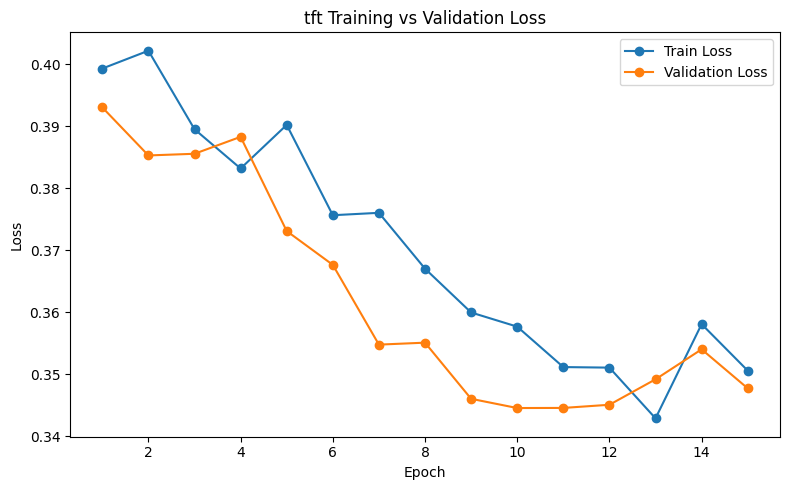

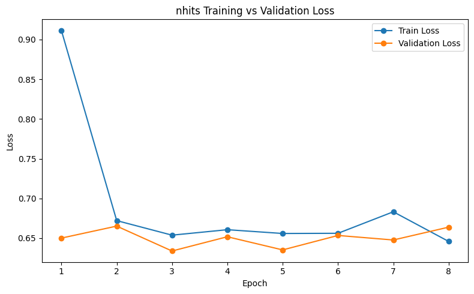

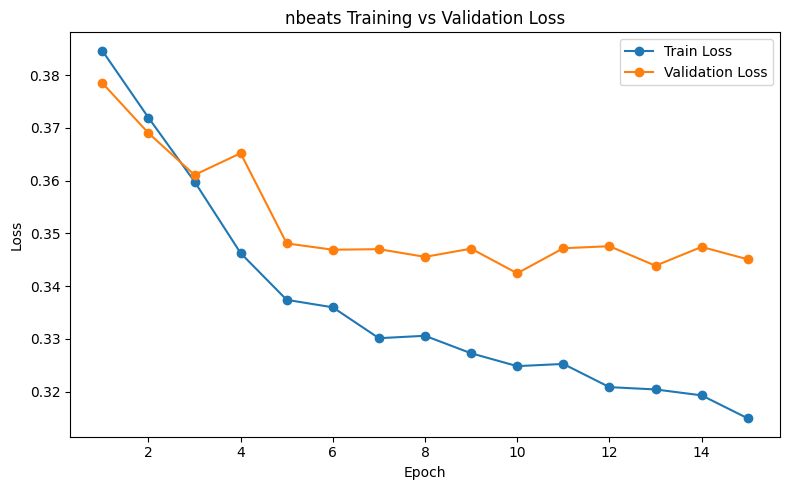

```python
import matplotlib.pyplot as plt

def plot_loss_curves_for_model(model_name: str):
    if model_name not in sequence_model_artifacts:
        print(f"{model_name} not found in sequence_model_artifacts")
        return

    hist = sequence_model_artifacts[model_name].get("loss_history_df")[1:]
    if hist is None or hist.empty:
        print(f"No loss history saved for {model_name}")
        return

    fig, ax = plt.subplots(figsize=(8, 5))

    if "train_loss" in hist.columns:
        ax.plot(hist["epoch"], hist["train_loss"], marker="o", label="Train Loss")

    if "val_loss" in hist.columns:
        ax.plot(hist["epoch"], hist["val_loss"], marker="o", label="Validation Loss")

    ax.set_title(f"{model_name} Training vs Validation Loss")
    ax.set_xlabel("Epoch")
    ax.set_ylabel("Loss")
    ax.legend()
    plt.tight_layout()
    plt.show()


for model_name in sequence_results_by_model.keys():
    plot_loss_curves_for_model(model_name)
```

```python
MODEL_TO_USE = best_model_name if "best_model_name" in globals() else "tft"
DRIVER_TO_USE = "VER"   # Max Verstappen
SOURCE_DF = test_race_df.copy()  # full target race in your current split


def get_saved_model_and_dataset(model_name: str):
    if (
        "sequence_model_artifacts" in globals()
        and model_name in sequence_model_artifacts
        and "best_model" in sequence_model_artifacts[model_name]
        and "train_dataset" in sequence_model_artifacts[model_name]
    ):
        return (
            sequence_model_artifacts[model_name]["best_model"],
            sequence_model_artifacts[model_name]["train_dataset"],
            sequence_model_artifacts[model_name].get("best_model_path", ""),
        )

    saved_results_lookup = None
    if "results_df" in globals() and isinstance(results_df, pd.DataFrame) and not results_df.empty:
        saved_results_lookup = results_df.copy()

    return resolve_model_artifact(
        model_name,
        feature_lists,
        saved_results_lookup=saved_results_lookup,
    )


def build_driver_window_for_any_lap(driver_df: pd.DataFrame, predict_lap_local: int) -> pd.DataFrame:
    work = driver_df.copy()

    if "time_idx" in work.columns:
        work = work.sort_values(["time_idx", "LapNumber"])
    else:
        work = work.sort_values("LapNumber")

    work = (
        work.drop_duplicates(subset=["LapNumber"], keep="last")
        .sort_values("LapNumber")
        .reset_index(drop=True)
    )

    if not (work["LapNumber"] == predict_lap_local).any():
        raise ValueError(f"LapNumber {predict_lap_local} is not present for this driver.")

    raw_required_len_local = MAX_ENCODER_LENGTH + MAX_PREDICTION_LENGTH + 1

    available_until_local = work[work["LapNumber"] <= predict_lap_local].copy()
    window_df_local = available_until_local.tail(raw_required_len_local).copy()

    if len(window_df_local) < raw_required_len_local:
        raise ValueError(
            f"Not enough context up to lap {predict_lap_local}. "
            f"Have {len(window_df_local)} rows, need {raw_required_len_local}."
        )

    _, window_filled_local, _ = fill_sequence_missing_values(
        train_race_df,
        window_df_local,
        window_df_local,
        feature_lists,
    )

    return window_filled_local


driver_event_df = SOURCE_DF[
    SOURCE_DF["Driver"].astype(str).str.upper() == DRIVER_TO_USE
].copy()

if driver_event_df.empty:
    available_drivers = sorted(SOURCE_DF["Driver"].dropna().astype(str).unique().tolist())
    raise ValueError(
        f"No rows found for driver {DRIVER_TO_USE!r}. "
        f"Available drivers in SOURCE_DF: {available_drivers}"
    )

driver_event_df = driver_event_df.sort_values(["LapNumber"]).copy()

target_year_local = int(driver_event_df["Year"].iloc[0])
target_round_local = int(driver_event_df["Round"].iloc[0])
target_event_name_local = str(driver_event_df["EventName"].iloc[0])

best_model_local, train_dataset_local, ckpt_path = get_saved_model_and_dataset(MODEL_TO_USE)

available_lap_numbers = sorted(driver_event_df["LapNumber"].dropna().astype(int).unique().tolist())

comparison_rows_driver = []

for lap_no in available_lap_numbers:
    try:
        window_filled_local = build_driver_window_for_any_lap(driver_event_df, lap_no)
    except ValueError:
        # early laps are expected to fail because there is not enough encoder history yet
        continue

    infer_dataset_local = TimeSeriesDataSet.from_dataset(
        train_dataset_local,
        window_filled_local,
        stop_randomization=True,
    )
    infer_loader_local = infer_dataset_local.to_dataloader(
        train=False,
        batch_size=BATCH_SIZE,
        num_workers=NUM_WORKERS,
    )

    pred_local = best_model_local.predict(infer_loader_local).detach().cpu().reshape(-1).numpy()
    pred_delta_s = float(pred_local[0]) if len(pred_local) else float("nan")

    current_row = window_filled_local.loc[
        window_filled_local["LapNumber"] == int(lap_no)
    ].copy()

    prev_lap_time_s = float(current_row["prev_lap_time_s"].mean())
    actual_lap_time_s = float(current_row["LapTime_s"].mean())
    pred_lap_time_s = prev_lap_time_s + pred_delta_s
    residual_s = pred_lap_time_s - actual_lap_time_s

    comparison_rows_driver.append({
        "model": MODEL_TO_USE,
        "driver": DRIVER_TO_USE,
        "year": target_year_local,
        "round": target_round_local,
        "event_name": target_event_name_local,
        "lap": int(lap_no),
        "prev_lap_time_s": prev_lap_time_s,
        "pred_delta_s": pred_delta_s,
        "pred_lap_time_s": pred_lap_time_s,
        "actual_lap_time_s": actual_lap_time_s,
        "residual_s": residual_s,
        "abs_error_s": abs(residual_s),
    })

driver_full_race_predictions = pd.DataFrame(comparison_rows_driver)

if driver_full_race_predictions.empty:
    raise ValueError(
        "No full-race predictions were generated. "
        "This usually means the driver does not have enough eligible laps after encoder-length filtering."
    )

driver_full_race_predictions = driver_full_race_predictions.sort_values("lap").reset_index(drop=True)

mean_signed_error_s = float(driver_full_race_predictions["residual_s"].mean())
median_signed_error_s = float(driver_full_race_predictions["residual_s"].median())
mae_s = float(driver_full_race_predictions["abs_error_s"].mean())
rmse_s = float(np.sqrt(np.mean(np.square(driver_full_race_predictions["residual_s"]))))

over_count = int((driver_full_race_predictions["residual_s"] > 0).sum())
under_count = int((driver_full_race_predictions["residual_s"] < 0).sum())
equal_count = int((driver_full_race_predictions["residual_s"] == 0).sum())
n_rows = len(driver_full_race_predictions)

if mean_signed_error_s > 0.05:
    bias_label = "tends to OVERPREDICT lap times"
elif mean_signed_error_s < -0.05:
    bias_label = "tends to UNDERPREDICT lap times"
else:
    bias_label = "is roughly BALANCED on average"

driver_bias_summary = pd.DataFrame([{
    "model": MODEL_TO_USE,
    "driver": DRIVER_TO_USE,
    "event_name": target_event_name_local,
    "predicted_laps": n_rows,
    "mae_s": mae_s,
    "rmse_s": rmse_s,
    "mean_signed_error_s": mean_signed_error_s,
    "median_signed_error_s": median_signed_error_s,
    "overpredicted_laps": over_count,
    "underpredicted_laps": under_count,
    "equal_laps": equal_count,
    "overpredicted_pct": 100.0 * over_count / n_rows,
    "underpredicted_pct": 100.0 * under_count / n_rows,
    "bias_label": bias_label,
}])

print(f"Driver-level full-race prediction for {DRIVER_TO_USE} using {MODEL_TO_USE}")
display(driver_bias_summary)
display(driver_full_race_predictions)
```

[output not shown]

[output cut: 176 more lines]

[output not shown]

```
Driver-level full-race prediction for VER using tft
```

|  | model | driver | event_name | predicted_laps | mae_s | rmse_s | mean_signed_error_s | median_signed_error_s | overpredicted_laps | underpredicted_laps | equal_laps | overpredicted_pct | underpredicted_pct | bias_label |
| --- | --- | --- | --- | --- | --- | --- | --- | --- | --- | --- | --- | --- | --- | --- |
| 0 | tft | VER | Italian Grand Prix | 33 | 0.170838 | 0.296735 | 0.014373 | -0.059415 | 11 | 22 | 0 | 33.333333 | 66.666667 | is roughly BALANCED on average |

|  | model | driver | year | round | event_name | lap | prev_lap_time_s | pred_delta_s | pred_lap_time_s | actual_lap_time_s | residual_s | abs_error_s |
| --- | --- | --- | --- | --- | --- | --- | --- | --- | --- | --- | --- | --- |
| 0 | tft | VER | 2025 | 16 | Italian Grand Prix | 19 | 82.727 | -0.069776 | 82.657224 | 82.838 | -0.180776 | 0.180776 |
| 1 | tft | VER | 2025 | 16 | Italian Grand Prix | 20 | 82.838 | -0.015790 | 82.822210 | 82.857 | -0.034790 | 0.034790 |
| 2 | tft | VER | 2025 | 16 | Italian Grand Prix | 21 | 82.857 | -0.021024 | 82.835976 | 82.919 | -0.083024 | 0.083024 |
| 3 | tft | VER | 2025 | 16 | Italian Grand Prix | 22 | 82.919 | -0.014549 | 82.904451 | 82.733 | 0.171451 | 0.171451 |
| 4 | tft | VER | 2025 | 16 | Italian Grand Prix | 23 | 82.733 | -0.040014 | 82.692986 | 82.782 | -0.089014 | 0.089014 |
| 5 | tft | VER | 2025 | 16 | Italian Grand Prix | 24 | 82.782 | -0.048504 | 82.733496 | 82.817 | -0.083504 | 0.083504 |
| 6 | tft | VER | 2025 | 16 | Italian Grand Prix | 25 | 82.817 | -0.032751 | 82.784249 | 82.970 | -0.185751 | 0.185751 |
| 7 | tft | VER | 2025 | 16 | Italian Grand Prix | 26 | 82.970 | -0.020174 | 82.949826 | 82.937 | 0.012826 | 0.012826 |
| 8 | tft | VER | 2025 | 16 | Italian Grand Prix | 27 | 82.937 | -0.012987 | 82.924013 | 83.015 | -0.090987 | 0.090987 |
| 9 | tft | VER | 2025 | 16 | Italian Grand Prix | 28 | 83.015 | -0.012905 | 83.002095 | 83.031 | -0.028905 | 0.028905 |
| 10 | tft | VER | 2025 | 16 | Italian Grand Prix | 29 | 83.031 | -0.009516 | 83.021484 | 82.811 | 0.210484 | 0.210484 |
| 11 | tft | VER | 2025 | 16 | Italian Grand Prix | 30 | 82.811 | -0.000136 | 82.810864 | 82.928 | -0.117136 | 0.117136 |
| 12 | tft | VER | 2025 | 16 | Italian Grand Prix | 31 | 82.928 | -0.025590 | 82.902410 | 82.941 | -0.038590 | 0.038590 |
| 13 | tft | VER | 2025 | 16 | Italian Grand Prix | 32 | 82.941 | -0.018634 | 82.922366 | 82.890 | 0.032366 | 0.032366 |
| 14 | tft | VER | 2025 | 16 | Italian Grand Prix | 33 | 82.890 | -0.012652 | 82.877348 | 82.943 | -0.065652 | 0.065652 |
| 15 | tft | VER | 2025 | 16 | Italian Grand Prix | 34 | 82.943 | -0.009153 | 82.933847 | 82.795 | 0.138847 | 0.138847 |
| 16 | tft | VER | 2025 | 16 | Italian Grand Prix | 35 | 82.795 | -0.001150 | 82.793850 | 82.651 | 0.142850 | 0.142850 |
| 17 | tft | VER | 2025 | 16 | Italian Grand Prix | 36 | 82.651 | 0.005029 | 82.656029 | 82.699 | -0.042971 | 0.042971 |
| 18 | tft | VER | 2025 | 16 | Italian Grand Prix | 39 | 82.699 | 0.015053 | 82.714053 | 81.402 | 1.312053 | 1.312053 |
| 19 | tft | VER | 2025 | 16 | Italian Grand Prix | 40 | 81.402 | -0.000690 | 81.401310 | 81.625 | -0.223690 | 0.223690 |
| 20 | tft | VER | 2025 | 16 | Italian Grand Prix | 41 | 81.625 | -0.008976 | 81.616024 | 81.358 | 0.258024 | 0.258024 |
| 21 | tft | VER | 2025 | 16 | Italian Grand Prix | 42 | 81.358 | -0.052296 | 81.305704 | 81.445 | -0.139296 | 0.139296 |
| 22 | tft | VER | 2025 | 16 | Italian Grand Prix | 43 | 81.445 | -0.012297 | 81.432703 | 81.320 | 0.112703 | 0.112703 |
| 23 | tft | VER | 2025 | 16 | Italian Grand Prix | 44 | 81.320 | -0.053865 | 81.266135 | 81.289 | -0.022865 | 0.022865 |
| 24 | tft | VER | 2025 | 16 | Italian Grand Prix | 45 | 81.289 | -0.023881 | 81.265119 | 81.353 | -0.087881 | 0.087881 |
| 25 | tft | VER | 2025 | 16 | Italian Grand Prix | 46 | 81.353 | -0.010167 | 81.342833 | 81.325 | 0.017833 | 0.017833 |
| 26 | tft | VER | 2025 | 16 | Italian Grand Prix | 47 | 81.325 | -0.064010 | 81.260990 | 81.336 | -0.075010 | 0.075010 |
| 27 | tft | VER | 2025 | 16 | Italian Grand Prix | 48 | 81.336 | -0.088156 | 81.247844 | 81.316 | -0.068156 | 0.068156 |
| 28 | tft | VER | 2025 | 16 | Italian Grand Prix | 49 | 81.316 | -0.083086 | 81.232914 | 81.328 | -0.095086 | 0.095086 |
| 29 | tft | VER | 2025 | 16 | Italian Grand Prix | 50 | 81.328 | -0.090415 | 81.237585 | 81.297 | -0.059415 | 0.059415 |
| 30 | tft | VER | 2025 | 16 | Italian Grand Prix | 51 | 81.297 | -0.098423 | 81.198577 | 81.749 | -0.550423 | 0.550423 |
| 31 | tft | VER | 2025 | 16 | Italian Grand Prix | 52 | 81.749 | -0.099455 | 81.649545 | 81.003 | 0.646545 | 0.646545 |
| 32 | tft | VER | 2025 | 16 | Italian Grand Prix | 53 | 81.003 | -0.121744 | 80.881256 | 81.100 | -0.218744 | 0.218744 |

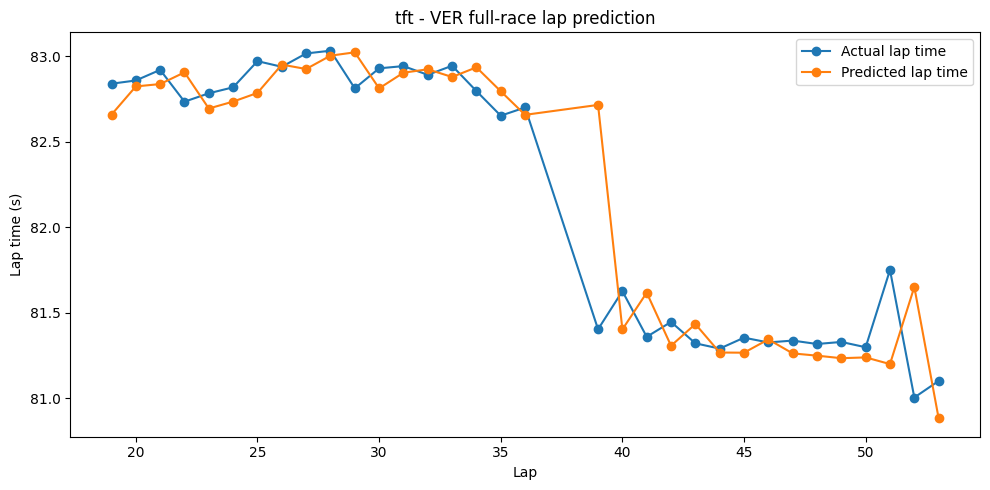

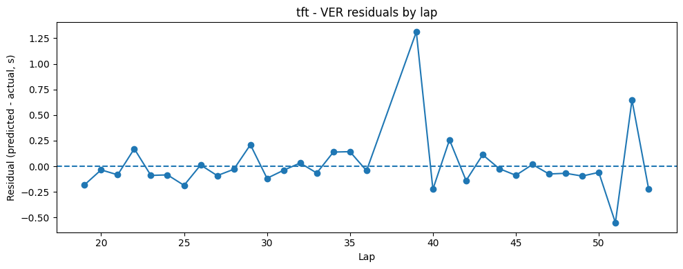

```python
import matplotlib.pyplot as plt

fig, ax = plt.subplots(figsize=(10, 5))
ax.plot(
    driver_full_race_predictions["lap"],
    driver_full_race_predictions["actual_lap_time_s"],
    marker="o",
    label="Actual lap time",
)
ax.plot(
    driver_full_race_predictions["lap"],
    driver_full_race_predictions["pred_lap_time_s"],
    marker="o",
    label="Predicted lap time",
)
ax.set_title(f"{MODEL_TO_USE} - {DRIVER_TO_USE} full-race lap prediction")
ax.set_xlabel("Lap")
ax.set_ylabel("Lap time (s)")
ax.legend()
plt.tight_layout()
plt.show()

fig, ax = plt.subplots(figsize=(10, 4))
ax.axhline(0.0, linestyle="--")
ax.plot(
    driver_full_race_predictions["lap"],
    driver_full_race_predictions["residual_s"],
    marker="o",
)
ax.set_title(f"{MODEL_TO_USE} - {DRIVER_TO_USE} residuals by lap")
ax.set_xlabel("Lap")
ax.set_ylabel("Residual (predicted - actual, s)")
plt.tight_layout()
plt.show()
```

As you can see from the first the lap 51 and 52 the model go very of the result on lap 51 the driver slower his pace by half a second compareded to the previous lap. The reason why it that is because the next lap Max Verstapen, most likely save engery from previous lap and deploy for lap 52where he tried to set the fastest time for the race. I will put link to verify this infonformation from the offical data https://www.formula1.com/en/results/2025/races/1268/italy/fastest-laps. The the most intersting part it that the model chacked that and predict almost perfectly the very similar time for the 51 in lap 52 and later after his attempt it acculy manages to adjust it self back to normal prediction which prof even feature that the model works very well.

```python
# Full-race lap-time prediction for ALL drivers in the selected test race
# using one already-trained saved model, without retraining.

import numpy as np
import pandas as pd
from pytorch_forecasting import TimeSeriesDataSet

MODEL_TO_USE = best_model_name if "best_model_name" in globals() else "nbeats"
SOURCE_DF = test_race_df.copy()   # should be the target race test split


def get_saved_model_and_dataset(model_name: str):
    if (
        "sequence_model_artifacts" in globals()
        and model_name in sequence_model_artifacts
        and "best_model" in sequence_model_artifacts[model_name]
        and "train_dataset" in sequence_model_artifacts[model_name]
    ):
        return (
            sequence_model_artifacts[model_name]["best_model"],
            sequence_model_artifacts[model_name]["train_dataset"],
            sequence_model_artifacts[model_name].get("best_model_path", ""),
        )

    saved_results_lookup = None
    if "results_df" in globals() and isinstance(results_df, pd.DataFrame) and not results_df.empty:
        saved_results_lookup = results_df.copy()

    return resolve_model_artifact(
        model_name,
        feature_lists,
        saved_results_lookup=saved_results_lookup,
    )


def build_driver_window_for_any_lap(driver_df: pd.DataFrame, predict_lap_local: int) -> pd.DataFrame:
    work = driver_df.copy()

    if "time_idx" in work.columns:
        work = work.sort_values(["time_idx", "LapNumber"])
    else:
        work = work.sort_values("LapNumber")

    work = (
        work.drop_duplicates(subset=["LapNumber"], keep="last")
        .sort_values("LapNumber")
        .reset_index(drop=True)
    )

    if not (work["LapNumber"] == predict_lap_local).any():
        raise ValueError(f"LapNumber {predict_lap_local} is not present for this driver.")

    raw_required_len_local = MAX_ENCODER_LENGTH + MAX_PREDICTION_LENGTH + 1

    available_until_local = work[work["LapNumber"] <= predict_lap_local].copy()
    window_df_local = available_until_local.tail(raw_required_len_local).copy()

    if len(window_df_local) < raw_required_len_local:
        raise ValueError(
            f"Not enough context up to lap {predict_lap_local}. "
            f"Have {len(window_df_local)} rows, need {raw_required_len_local}."
        )

    _, window_filled_local, _ = fill_sequence_missing_values(
        train_race_df,
        window_df_local,
        window_df_local,
        feature_lists,
    )

    return window_filled_local


if SOURCE_DF.empty:
    raise ValueError("SOURCE_DF is empty.")

if "selected_target_event_id" in globals() and "event_id" in SOURCE_DF.columns:
    source_event_df = SOURCE_DF[SOURCE_DF["event_id"] == selected_target_event_id].copy()
    if source_event_df.empty:
        source_event_df = SOURCE_DF.copy()
else:
    source_event_df = SOURCE_DF.copy()

if source_event_df.empty:
    raise ValueError("No rows found for the selected event.")

target_year_local = int(source_event_df["Year"].iloc[0])
target_round_local = int(source_event_df["Round"].iloc[0])
target_event_name_local = str(source_event_df["EventName"].iloc[0])

best_model_local, train_dataset_local, ckpt_path = get_saved_model_and_dataset(MODEL_TO_USE)

all_drivers = sorted(source_event_df["Driver"].dropna().astype(str).unique().tolist())
comparison_rows_all_drivers = []

for driver_code in all_drivers:
    driver_event_df = source_event_df[
        source_event_df["Driver"].astype(str).str.upper() == driver_code
    ].copy()

    if driver_event_df.empty:
        continue

    driver_event_df = driver_event_df.sort_values("LapNumber").copy()
    available_lap_numbers = sorted(driver_event_df["LapNumber"].dropna().astype(int).unique().tolist())

    for lap_no in available_lap_numbers:
        try:
            window_filled_local = build_driver_window_for_any_lap(driver_event_df, lap_no)
        except ValueError:
            # early laps are expected to fail because there is not enough encoder history yet
            continue

        infer_dataset_local = TimeSeriesDataSet.from_dataset(
            train_dataset_local,
            window_filled_local,
            stop_randomization=True,
        )
        infer_loader_local = infer_dataset_local.to_dataloader(
            train=False,
            batch_size=BATCH_SIZE,
            num_workers=NUM_WORKERS,
        )

        pred_local = best_model_local.predict(infer_loader_local).detach().cpu().reshape(-1).numpy()
        pred_delta_s = float(pred_local[0]) if len(pred_local) else float("nan")

        current_row = window_filled_local.loc[
            window_filled_local["LapNumber"] == int(lap_no)
        ].copy()

        prev_lap_time_s = float(current_row["prev_lap_time_s"].mean())
        actual_lap_time_s = float(current_row["LapTime_s"].mean())
        pred_lap_time_s = prev_lap_time_s + pred_delta_s
        residual_s = pred_lap_time_s - actual_lap_time_s

        comparison_rows_all_drivers.append({
            "model": MODEL_TO_USE,
            "driver": driver_code,
            "year": target_year_local,
            "round": target_round_local,
            "event_name": target_event_name_local,
            "lap": int(lap_no),
            "prev_lap_time_s": prev_lap_time_s,
            "pred_delta_s": pred_delta_s,
            "pred_lap_time_s": pred_lap_time_s,
            "actual_lap_time_s": actual_lap_time_s,
            "residual_s": residual_s,
            "abs_error_s": abs(residual_s),
        })

all_drivers_full_race_predictions = pd.DataFrame(comparison_rows_all_drivers)

if all_drivers_full_race_predictions.empty:
    raise ValueError(
        "No full-race predictions were generated for any driver. "
        "This usually means there is not enough encoder context."
    )

all_drivers_full_race_predictions = (
    all_drivers_full_race_predictions
    .sort_values(["driver", "lap"])
    .reset_index(drop=True)
)

driver_race_error_summary = (
    all_drivers_full_race_predictions
    .groupby("driver", as_index=False)
    .agg(
        predicted_laps=("lap", "count"),
        sum_abs_error_s=("abs_error_s", "sum"),
        avg_abs_error_s=("abs_error_s", "mean"),
        rmse_s=("residual_s", lambda x: float(np.sqrt(np.mean(np.square(x))))),
        mean_signed_error_s=("residual_s", "mean"),
        median_signed_error_s=("residual_s", "median"),
        best_abs_error_s=("abs_error_s", "min"),
        worst_abs_error_s=("abs_error_s", "max"),
    )
    .sort_values(["avg_abs_error_s", "sum_abs_error_s"], ascending=[True, True])
    .reset_index(drop=True)
)

driver_race_error_summary["bias_label"] = np.where(
    driver_race_error_summary["mean_signed_error_s"] > 0.05,
    "overpredict",
    np.where(
        driver_race_error_summary["mean_signed_error_s"] < -0.05,
        "underpredict",
        "roughly_balanced",
    )
)

print(f"Full-race driver summary using model {MODEL_TO_USE} for {target_event_name_local} ({target_year_local} R{target_round_local})")
display(driver_race_error_summary)
```

[output not shown]

[output cut: 3935 more lines]

[output not shown]

```
Full-race driver summary using model nbeats for Italian Grand Prix (2025 R16)
```

|  | driver | predicted_laps | sum_abs_error_s | avg_abs_error_s | rmse_s | mean_signed_error_s | median_signed_error_s | best_abs_error_s | worst_abs_error_s | bias_label |
| --- | --- | --- | --- | --- | --- | --- | --- | --- | --- | --- |
| 0 | ALO | 3 | 0.387064 | 0.129021 | 0.171684 | 0.082954 | 0.030332 | 0.030332 | 0.287630 | overpredict |
| 1 | OCO | 32 | 4.588898 | 0.143403 | 0.171430 | -0.013349 | 0.006835 | 0.002535 | 0.320717 | roughly_balanced |
| 2 | VER | 33 | 6.768029 | 0.205092 | 0.322787 | -0.028175 | -0.071827 | 0.006260 | 1.324090 | roughly_balanced |
| 3 | RUS | 32 | 7.237392 | 0.226168 | 0.356974 | -0.027757 | -0.065172 | 0.009242 | 1.454758 | roughly_balanced |
| 4 | BEA | 32 | 7.837003 | 0.244906 | 0.335569 | -0.064094 | -0.025209 | 0.019671 | 1.113035 | underpredict |
| 5 | HAM | 33 | 8.427196 | 0.255370 | 0.326327 | -0.035401 | -0.053416 | 0.007516 | 0.778463 | roughly_balanced |
| 6 | ALB | 32 | 8.312496 | 0.259765 | 0.373361 | -0.011868 | 0.005703 | 0.017817 | 1.179680 | roughly_balanced |
| 7 | LEC | 32 | 8.809648 | 0.275302 | 0.365968 | -0.042644 | 0.049938 | 0.003418 | 1.083620 | roughly_balanced |
| 8 | HAD | 31 | 8.603174 | 0.277522 | 0.436636 | -0.067362 | -0.073060 | 0.016904 | 1.316631 | underpredict |
| 9 | STR | 31 | 9.884601 | 0.318858 | 0.424472 | -0.007172 | 0.005203 | 0.000610 | 0.986229 | roughly_balanced |
| 10 | BOR | 32 | 10.281825 | 0.321307 | 0.421539 | -0.039380 | 0.024735 | 0.009611 | 1.352442 | roughly_balanced |
| 11 | NOR | 33 | 10.712685 | 0.324627 | 0.485487 | -0.021808 | -0.049963 | 0.010574 | 1.783567 | roughly_balanced |
| 12 | GAS | 28 | 10.338780 | 0.369242 | 0.704000 | -0.051775 | 0.097991 | 0.010399 | 2.328890 | underpredict |
| 13 | SAI | 30 | 11.218439 | 0.373948 | 0.526200 | -0.059096 | 0.013626 | 0.015041 | 1.311292 | underpredict |
| 14 | PIA | 33 | 12.941796 | 0.392176 | 0.604471 | -0.093513 | -0.062918 | 0.028682 | 1.668269 | underpredict |
| 15 | TSU | 32 | 13.013744 | 0.406680 | 0.589141 | -0.049127 | 0.043888 | 0.002025 | 1.568589 | roughly_balanced |
| 16 | ANT | 30 | 12.270364 | 0.409012 | 0.595665 | -0.108132 | -0.013748 | 0.004547 | 1.483431 | underpredict |
| 17 | LAW | 32 | 14.000721 | 0.437523 | 0.611724 | -0.126402 | -0.035736 | 0.001651 | 1.680905 | underpredict |
| 18 | COL | 29 | 16.570034 | 0.571380 | 0.867379 | -0.143091 | -0.091801 | 0.027642 | 2.331508 | underpredict |

I have created this table to show each drivers values from the best model for their predion for all lap times during the race. The best driver that predict most accurate is being Ocon with total error for the course of the entire race time 4.5 seconds with average lap time of 0.14, which perfect mean value close to 0 which it is very balanced in it predition.The think that I am most supprised if how good it predic the lap time of Alonso, which drive only 24 (we predict from lap 20) laps and most likely have some technical problems or crash and retire from the race you can see the offical results here https://www.formula1.com/en/results/2025/races/1268/italy/race-result and that explaing showing only 19 driver becasue Hulkeberd did not start at all.

Another thing that if also noticable is last few drivers with the worst prediction of all that being Antonelli, Lawson and Colopinto the reason these driver prediction is the 'worst' compare to the others is the fact that the 2025 was the year of the rokies(new driver in the sport) and for these partical drivers they dont have any information in the previous year. Something even more spefic about Anotonelli is her is also driving for Merceder a team that is in 3-4 during that session and it replacing Hamilton seat, which win 7 WDC so the model is more or less trying to make him perform as well as he does in the previous each, but on the other side the his teammate Russell, which has been racing for this team all the 3 years used in the dataset got the 4 best prediction. The same thing can be said for Bearman which is the teammate of Ocon and just for the same reason he is rank a bit lower.

The other thing that suprice me is how it predict the Mclaren driver Norris and Piastri despite being the fastest team for the overall season, just becasue they had improve way more the car from 2023-2025 from 4 fastest to 1 fastest car some times the model on can go up to 1.7 sec off in the worst cases.

```python
race_all_drivers_error_summary = pd.DataFrame([{
    "predicted_laps_total": int(len(all_drivers_full_race_predictions)),
    "total_actual_race_time_s": float(all_drivers_full_race_predictions["actual_lap_time_s"].sum()),
    "total_predicted_race_time_s": float(all_drivers_full_race_predictions["pred_lap_time_s"].sum()),
    "total_signed_error_s": float(all_drivers_full_race_predictions["residual_s"].sum()),
    "avg_signed_error_s": float(all_drivers_full_race_predictions["residual_s"].mean()),
    "total_abs_error_s": float(all_drivers_full_race_predictions["abs_error_s"].sum()),
    "avg_abs_error_s": float(all_drivers_full_race_predictions["abs_error_s"].mean()),
}])

race_all_drivers_error_summary["total_race_time_error_pct"] = (
    (race_all_drivers_error_summary["total_actual_race_time_s"] - race_all_drivers_error_summary["total_predicted_race_time_s"]).abs()
    / race_all_drivers_error_summary["total_actual_race_time_s"]
    * 100.0
)

race_all_drivers_error_summary["total_race_time_closeness_pct"] = (
    100.0 - race_all_drivers_error_summary["total_race_time_error_pct"]
)

display(race_all_drivers_error_summary)
```

|  | predicted_laps_total | total_actual_race_time_s | total_predicted_race_time_s | total_signed_error_s | avg_signed_error_s | total_abs_error_s | avg_abs_error_s | total_race_time_error_pct | total_race_time_closeness_pct |
| --- | --- | --- | --- | --- | --- | --- | --- | --- | --- |
| 0 | 570 | 47307.898 | 47277.328718 | -30.569282 | -0.05363 | 182.203888 | 0.319656 | 0.064618 | 99.935382 |

## Conclussion

I deam this model very good based on what I start at the beginning of this project with models with gap of 9 seconds which is a lot as I explaing a bit earlier. After very carefully data reading and filtering the most improtant feature going to telemetry data which in my opinion is like 50% off the successful prediction because it record every driver movement to the car 10 times every 1 sec. I think I have applied the best possible tactics like rolling window to get every bit of the performance. I also believe this is just still mediam level model, if this project get up scale to the entire race calendar of 24 races how it was planned to do, it will learn even better the pattern like Verstappen trying to put the fastest lap at the end of the race, and will have more data for referances and the overall the MAE in my opnion will go down to at least 0.150- 0.200 sec per lap. For the use of this model, I believe such a project will be more in use for the actual racing teams like Ferrari, Red Bull and Mercedes, or people that are really into every information of the sport not the casual user. The reason why I am saying that is,because for the normal user they can use such a model to simulate races before the actual race to understnad what result to expect from their favorite driver, but to make it real this sport is every driven by unexpected event like crashes though the beginning middle and the end of the races with mixes of unexpected weather condition, it will be harding to take them into account before the actual race happpens. On the other hand if someone from the team like race enginner use such a model it can help them like a tool to determ, how the drivers is performing live time with hte needed computing power, because such a model should be rerun every lap to give proper result and base of the result to help them to make the best race strategy like, pitting earlier if they see that their time slow down compare to the competitor, to keep their position if they are being chased.